# Global Airbnb Insights: A Comparative Study of New York, Paris, and Tokyo’s Rental Markets and Trends

### Author: Pietro Tegon

### Introduction: Airbnb's adaptability across cities

Airbnb, founded in 2008, has rapidly transformed the landscape of global travel and accommodation. As an online marketplace, it connects hosts offering unique lodging spaces with travelers seeking alternatives to traditional hotels. By leveraging technology, Airbnb has enabled millions of people to monetize their homes and share their local cultures with guests from around the world. This innovative model not only provides travelers with a variety of lodging options, ranging from budget-friendly rooms to luxury villas, but also fosters a more authentic travel experience by immersing guests in local communities.. This project examines the influence and use of Airbnb in three major cities across three different continents: Paris, Tokyo, and New York. Each city presents a unique cultural and social landscape, demonstrating how Airbnb adapts to diverse environments.

In Paris, the romantic and historic ambiance of the city is reflected in the variety of accommodations offered, allowing travelers to experience the city’s charm from within its neighborhoods. Tokyo, a city that blends the ultramodern with the traditional, provides a different dynamic, where Airbnb enables visitors to enjoy a local experience amidst the city’s fast-paced environment. New York City, known for its cultural diversity and vibrant urban life, showcases Airbnb’s ability to cater to a wide range of tastes and preferences, offering everything from trendy apartments in Manhattan to cozy spaces in Brooklyn.

This projects examines the differences in Airbnb stays in these three cities, which can range from price to type of stay to the difference between neighboorhoods within each city. Additionally, each city's Airbnbs will be examined on their own, to better understand trends, internal differences between neighborhoods or correlation between price and other variables.

### Datasets

- listings_paris.csv
- listings_tokyo.csv
- reviews_paris.csv
- reviews_tokyo.csv
- reviews_ny.csv

Source: https://insideairbnb.com/get-the-data/

- Airbnb_Open_Data_ny.csv

Source: https://www.kaggle.com/datasets/arianazmoudeh/airbnbopendata

### Research questions

The questions that will be used as guidelines throughout this notebook are:

- What are the differences between the three cities?
- For each city, are there internal differences? Which ones?
- Which trends in tourism or price have these cities been following?

The selection of the datasets and all the steps taken towards the analysis of the data will be functional to the answer of the research questions.

### Project overview and methodology

The project will be divided in four parts:

- Part 1: Installing and importing necessary libraries
- Part 2: Data cleaning
- Part 3: Data combining and reshaping
- Part 4: Data analisys and visualization

## Part 1 - Installing and importing necessary libraries

First of all, we need to install all of the libraries which we are going to use throughout the project.

```python
%pip install pandas numpy matplotlib seaborn geopandas plotly
```

Now that they are installed, we need to import them so their functions can be used.

```python
import pandas as pd  # Data manipulation and analysis library

import numpy as np  # Numerical computing library

import matplotlib.pyplot as plt  # Plotting library

import seaborn as sns  # Statistical data visualization library (built on top of matplotlib)

import geopandas as gpd  # Geographic data analysis library (works with pandas for geospatial data)

import plotly.express as px  # Interactive plotting library (high-level interface for data visualization)

import warnings
warnings.filterwarnings('ignore')  # Suppresses unwanted warnings
```

## Part 2: Data cleaning

### First dataset: Paris

This first dataset contains information about the city of Paris. The first thing to do is selecting the columns which are going to be useful to answer our questions.

```python
listings_paris = pd.read_csv('listings_paris.csv')

listings_paris
```

|  | id | name | host_id | host_name | neighbourhood_group | neighbourhood | latitude | longitude | room_type | price | minimum_nights | number_of_reviews | last_review | reviews_per_month | calculated_host_listings_count | availability_365 | number_of_reviews_ltm | license |
| --- | --- | --- | --- | --- | --- | --- | --- | --- | --- | --- | --- | --- | --- | --- | --- | --- | --- | --- |
| 0 | 7241227 | Appartement F2 de 50m2 | 23740469 | Marie Josee | NaN | Buttes-Montmartre | 48.889930 | 2.366960 | Entire home/apt | NaN | 365 | 2 | 2018-08-25 | 0.03 | 1 | 0 | 0 | NaN |
| 1 | 738818740125140768 | Studette calme paris | 33108376 | Kaïs | NaN | Passy | 48.852160 | 2.262300 | Entire home/apt | NaN | 4 | 6 | 2023-09-26 | 0.30 | 1 | 0 | 2 | 7511607442416 |
| 2 | 6640639 | Chambre de Bonne | 34756427 | Ricardo | NaN | Vaugirard | 48.831000 | 2.289190 | Entire home/apt | NaN | 365 | 0 | NaN | NaN | 1 | 0 | 0 | NaN |
| 3 | 8387171 | Faidherbe Chaligny Square | 44188365 | Benoit | NaN | Reuilly | 48.848980 | 2.386090 | Entire home/apt | NaN | 365 | 0 | NaN | NaN | 1 | 0 | 0 | NaN |
| 4 | 1097932353733680407 | Beau studio au cœur de Barbès | 514983472 | Rebaia | NaN | Buttes-Montmartre | 48.886598 | 2.359753 | Entire home/apt | NaN | 1 | 2 | 2024-04-07 | 0.59 | 1 | 0 | 2 | 7511808567461 |
| ... | ... | ... | ... | ... | ... | ... | ... | ... | ... | ... | ... | ... | ... | ... | ... | ... | ... | ... |
| 95880 | 1141100956738233414 | Résidor - Superb studio in the heart of Paris 2P | 542390760 | Juliette | NaN | Reuilly | 48.850558 | 2.371702 | Entire home/apt | 70.0 | 1 | 0 | NaN | NaN | 63 | 152 | 0 | 7511212870467 |
| 95881 | 1097772613643886884 | Cosy nest 200m from the Pantheon | 518630207 | Eliot | NaN | Panthéon | 48.849240 | 2.346370 | Entire home/apt | 130.0 | 2 | 0 | NaN | NaN | 1 | 256 | 0 | 7510513886487 |
| 95882 | 16117980 | Wonderful apartment Luxemburg 6eme | 30583681 | Gaia | NaN | Luxembourg | 48.849160 | 2.341380 | Entire home/apt | 249.0 | 30 | 12 | 2024-05-18 | 0.13 | 5 | 316 | 7 | Available with a mobility lease only ("bail mo... |
| 95883 | 641029927221252082 | Blueground \| Pigalle, balcony, nr shops & dining | 314994947 | Blueground | NaN | Opéra | 48.882538 | 2.348971 | Entire home/apt | 79.0 | 31 | 1 | 2023-02-28 | 0.06 | 730 | 311 | 0 | Available with a mobility lease only ("bail mo... |
| 95884 | 3243451 | au calme dans quartier vivant | 16410142 | Samir Ou Louis | NaN | Buttes-Montmartre | 48.886530 | 2.352980 | Entire home/apt | 430.0 | 3 | 3 | 2015-09-07 | 0.03 | 1 | 53 | 0 | 7511812203278 |

95885 rows × 18 columns

```python
# List of columns to drop
columns_to_drop = ['name', 'host_id', 'host_name', 'neighbourhood_group',
                   'number_of_reviews', 'number_of_reviews_ltm', 'license', 'calculated_host_listings_count']

# Drop the columns
listings_paris = listings_paris.drop(columns=columns_to_drop)

# Display the first few rows of the DataFrame to confirm the changes

listings_paris
```

|  | id | neighbourhood | latitude | longitude | room_type | price | minimum_nights | last_review | reviews_per_month | availability_365 |
| --- | --- | --- | --- | --- | --- | --- | --- | --- | --- | --- |
| 0 | 7241227 | Buttes-Montmartre | 48.889930 | 2.366960 | Entire home/apt | NaN | 365 | 2018-08-25 | 0.03 | 0 |
| 1 | 738818740125140768 | Passy | 48.852160 | 2.262300 | Entire home/apt | NaN | 4 | 2023-09-26 | 0.30 | 0 |
| 2 | 6640639 | Vaugirard | 48.831000 | 2.289190 | Entire home/apt | NaN | 365 | NaN | NaN | 0 |
| 3 | 8387171 | Reuilly | 48.848980 | 2.386090 | Entire home/apt | NaN | 365 | NaN | NaN | 0 |
| 4 | 1097932353733680407 | Buttes-Montmartre | 48.886598 | 2.359753 | Entire home/apt | NaN | 1 | 2024-04-07 | 0.59 | 0 |
| ... | ... | ... | ... | ... | ... | ... | ... | ... | ... | ... |
| 95880 | 1141100956738233414 | Reuilly | 48.850558 | 2.371702 | Entire home/apt | 70.0 | 1 | NaN | NaN | 152 |
| 95881 | 1097772613643886884 | Panthéon | 48.849240 | 2.346370 | Entire home/apt | 130.0 | 2 | NaN | NaN | 256 |
| 95882 | 16117980 | Luxembourg | 48.849160 | 2.341380 | Entire home/apt | 249.0 | 30 | 2024-05-18 | 0.13 | 316 |
| 95883 | 641029927221252082 | Opéra | 48.882538 | 2.348971 | Entire home/apt | 79.0 | 31 | 2023-02-28 | 0.06 | 311 |
| 95884 | 3243451 | Buttes-Montmartre | 48.886530 | 2.352980 | Entire home/apt | 430.0 | 3 | 2015-09-07 | 0.03 | 53 |

95885 rows × 10 columns

These are the selected columns:

- ID: Unique identifier for each Airbnb listing.
- Neighbourhood: The specific area or district where the listing is located within the city.
- Latitude: Geographic latitude coordinate of the listing's location.
- Longitude: Geographic longitude coordinate of the listing's location.
- Room Type: Type of accommodation offered (e.g., entire home, private room, shared room).
- Price: Cost per night in local currency for staying at the listing.
- Minimum Nights: The minimum number of nights required to book the listing.
- Last Review: The date of the most recent review left by a guest.
- Reviews per Month: Average number of reviews the listing receives each month.
- Availability 365: Number of days the listing is available for booking throughout the year.

Now we need to handle the NaN values. I will remove all rows with a NaN in the price column, because it is one of the main parameters considered in the analysis, while I'll subsitute the others with 0s.

```python
# Check for NaN values in the 'price' column
nan_count_before = listings_paris['price'].isna().sum()
print(f"Number of NaNs in 'price' column before removal: {nan_count_before}")

# Remove rows with NaN values in the 'price' column
listings_paris = listings_paris.dropna(subset=['price'])

# You can also check the number of rows before and after the operation
print(f"Number of rows before removing NaNs: {nan_count_before + listings_paris.shape[0]}")
print(f"Number of rows after removing NaNs: {listings_paris.shape[0]}")
```

```
Number of NaNs in 'price' column before removal: 21306
Number of rows before removing NaNs: 95885
Number of rows after removing NaNs: 74579
```

```python
# Fill NaNs in the entire DataFrame with 0
listings_paris = listings_paris.fillna(0)

listings_paris
```

|  | id | neighbourhood | latitude | longitude | room_type | price | minimum_nights | last_review | reviews_per_month | availability_365 |
| --- | --- | --- | --- | --- | --- | --- | --- | --- | --- | --- |
| 13 | 907334372443748916 | Buttes-Montmartre | 48.893101 | 2.343294 | Entire home/apt | 180.0 | 4 | 0 | 0.00 | 56 |
| 15 | 748622699683505970 | Buttes-Montmartre | 48.886903 | 2.346189 | Entire home/apt | 98.0 | 2 | 2023-07-01 | 1.53 | 84 |
| 17 | 39075508 | Buttes-Montmartre | 48.891640 | 2.341430 | Entire home/apt | 250.0 | 3 | 2023-10-22 | 0.86 | 132 |
| 19 | 1143374758553613989 | Buttes-Montmartre | 48.891924 | 2.346870 | Entire home/apt | 170.0 | 3 | 2024-06-07 | 1.00 | 35 |
| 20 | 752590421915936661 | Opéra | 48.880810 | 2.334850 | Entire home/apt | 77.0 | 4 | 2024-06-08 | 1.62 | 237 |
| ... | ... | ... | ... | ... | ... | ... | ... | ... | ... | ... |
| 95880 | 1141100956738233414 | Reuilly | 48.850558 | 2.371702 | Entire home/apt | 70.0 | 1 | 0 | 0.00 | 152 |
| 95881 | 1097772613643886884 | Panthéon | 48.849240 | 2.346370 | Entire home/apt | 130.0 | 2 | 0 | 0.00 | 256 |
| 95882 | 16117980 | Luxembourg | 48.849160 | 2.341380 | Entire home/apt | 249.0 | 30 | 2024-05-18 | 0.13 | 316 |
| 95883 | 641029927221252082 | Opéra | 48.882538 | 2.348971 | Entire home/apt | 79.0 | 31 | 2023-02-28 | 0.06 | 311 |
| 95884 | 3243451 | Buttes-Montmartre | 48.886530 | 2.352980 | Entire home/apt | 430.0 | 3 | 2015-09-07 | 0.03 | 53 |

74579 rows × 10 columns

About 20 thousand rows have been removed. Now, to have a uniform statistic across all datasets I will convert the price in Euros to dollars.

```python
# Define the conversion rate from EUR to USD
conversion_rate_eur_to_usd = 1 / 0.89  # Example: 1 USD = 0.85 EUR

# Convert the 'price' column from EUR to USD
listings_paris['price'] = listings_paris['price'] * conversion_rate_eur_to_usd

# Verify the changes by displaying the first few rows
print(listings_paris[['price']].head())
```

```
         price
13  202.247191
15  110.112360
17  280.898876
19  191.011236
20   86.516854
```

Going through the raw dataset I saw some outliers, which had prices above 40 thousand euros per night, so I will count how many values are above the 3000 $ treshold and then I will remove them.

```python
# Filter the DataFrame to get rows where 'price' is greater than 3000
filtered_df = listings_paris[listings_paris['price'] > 3000]

# Select only the unique 'id' values from the filtered DataFrame
unique_ids_with_high_price = filtered_df['id'].unique()

# Get the number of unique IDs
number_of_unique_ids = len(unique_ids_with_high_price)

# Print the result
print(f"Number of unique IDs with price > 3000: {number_of_unique_ids}")
```

```
Number of unique IDs with price > 3000: 487
```

It is a very small number compared to the number of rows, so we can eliminate those rows.

```python
# Filter the DataFrame to get rows where 'price' is greater than 3000
filtered_paris = listings_paris[listings_paris['price'] < 3000]

filtered_paris.head()
```

|  | id | neighbourhood | latitude | longitude | room_type | price | minimum_nights | last_review | reviews_per_month | availability_365 |
| --- | --- | --- | --- | --- | --- | --- | --- | --- | --- | --- |
| 13 | 907334372443748916 | Buttes-Montmartre | 48.893101 | 2.343294 | Entire home/apt | 202.247191 | 4 | 0 | 0.00 | 56 |
| 15 | 748622699683505970 | Buttes-Montmartre | 48.886903 | 2.346189 | Entire home/apt | 110.112360 | 2 | 2023-07-01 | 1.53 | 84 |
| 17 | 39075508 | Buttes-Montmartre | 48.891640 | 2.341430 | Entire home/apt | 280.898876 | 3 | 2023-10-22 | 0.86 | 132 |
| 19 | 1143374758553613989 | Buttes-Montmartre | 48.891924 | 2.346870 | Entire home/apt | 191.011236 | 3 | 2024-06-07 | 1.00 | 35 |
| 20 | 752590421915936661 | Opéra | 48.880810 | 2.334850 | Entire home/apt | 86.516854 | 4 | 2024-06-08 | 1.62 | 237 |

### Second dataset: Tokyo

This second dataset contains information about the city of Tokyo. The steps which will be followed are exactly the same as the ones followed for Paris, since the columns are the same.

```python
listings_tokyo = pd.read_csv('listings_tokyo.csv')

listings_tokyo.head()
```

|  | id | name | host_id | host_name | neighbourhood_group | neighbourhood | latitude | longitude | room_type | price | minimum_nights | number_of_reviews | last_review | reviews_per_month | calculated_host_listings_count | availability_365 | number_of_reviews_ltm | license |
| --- | --- | --- | --- | --- | --- | --- | --- | --- | --- | --- | --- | --- | --- | --- | --- | --- | --- | --- |
| 0 | 197677 | Oshiage Holiday Apartment | 964081 | Yoshimi & Marek | NaN | Sumida Ku | 35.717070 | 139.826080 | Entire home/apt | 12000.0 | 3 | 176 | 2024-05-15 | 1.13 | 1 | 223 | 4 | M130003350 |
| 1 | 776070 | Kero-kero house room 1 | 801494 | Kei | NaN | Kita Ku | 35.738440 | 139.769170 | Private room | 9652.0 | 3 | 256 | 2024-06-03 | 1.81 | 1 | 173 | 13 | M130000243 |
| 2 | 905944 | 4F - Near Shinjuku & Shibuya | 4847803 | Best Stay In Tokyo! | NaN | Shibuya Ku | 35.678780 | 139.678470 | Entire home/apt | 25738.0 | 3 | 219 | 2024-06-19 | 1.60 | 6 | 115 | 33 | Hotels and Inns Business Act \| 渋谷区保健所長 \| 31渋健生... |
| 3 | 1016831 | 5 mins Shibuya Cat modern sunny Shimokita | 5596383 | Wakana | NaN | Setagaya Ku | 35.658000 | 139.671340 | Private room | 23286.0 | 10 | 268 | 2024-06-26 | 1.96 | 2 | 129 | 24 | M130001107 |
| 4 | 1196177 | Stay with host Cozy private room Senju area | 5686404 | Yukiko | NaN | Adachi Ku | 35.744731 | 139.797384 | Private room | 7500.0 | 2 | 120 | 2024-06-15 | 0.91 | 1 | 36 | 26 | M130007760 |

I will take the exact same columns as the Paris dataset.

```python
# Step 1: Get the list of columns from the modified listings_paris DataFrame
paris_columns = listings_paris.columns.tolist()

# Select only the columns that are in paris_columns
listings_tokyo = listings_tokyo[paris_columns]

listings_tokyo.head()
```

|  | id | neighbourhood | latitude | longitude | room_type | price | minimum_nights | last_review | reviews_per_month | availability_365 |
| --- | --- | --- | --- | --- | --- | --- | --- | --- | --- | --- |
| 0 | 197677 | Sumida Ku | 35.717070 | 139.826080 | Entire home/apt | 12000.0 | 3 | 2024-05-15 | 1.13 | 223 |
| 1 | 776070 | Kita Ku | 35.738440 | 139.769170 | Private room | 9652.0 | 3 | 2024-06-03 | 1.81 | 173 |
| 2 | 905944 | Shibuya Ku | 35.678780 | 139.678470 | Entire home/apt | 25738.0 | 3 | 2024-06-19 | 1.60 | 115 |
| 3 | 1016831 | Setagaya Ku | 35.658000 | 139.671340 | Private room | 23286.0 | 10 | 2024-06-26 | 1.96 | 129 |
| 4 | 1196177 | Adachi Ku | 35.744731 | 139.797384 | Private room | 7500.0 | 2 | 2024-06-15 | 0.91 | 36 |

```python
# Remove rows with NaN values in the 'price' column
listings_tokyo = listings_tokyo.dropna(subset=['price'])

# Fill NaNs in the entire DataFrame with 0
listings_tokyo = listings_tokyo.fillna(0)

listings_tokyo.head()
```

|  | id | neighbourhood | latitude | longitude | room_type | price | minimum_nights | last_review | reviews_per_month | availability_365 |
| --- | --- | --- | --- | --- | --- | --- | --- | --- | --- | --- |
| 0 | 197677 | Sumida Ku | 35.717070 | 139.826080 | Entire home/apt | 12000.0 | 3 | 2024-05-15 | 1.13 | 223 |
| 1 | 776070 | Kita Ku | 35.738440 | 139.769170 | Private room | 9652.0 | 3 | 2024-06-03 | 1.81 | 173 |
| 2 | 905944 | Shibuya Ku | 35.678780 | 139.678470 | Entire home/apt | 25738.0 | 3 | 2024-06-19 | 1.60 | 115 |
| 3 | 1016831 | Setagaya Ku | 35.658000 | 139.671340 | Private room | 23286.0 | 10 | 2024-06-26 | 1.96 | 129 |
| 4 | 1196177 | Adachi Ku | 35.744731 | 139.797384 | Private room | 7500.0 | 2 | 2024-06-15 | 0.91 | 36 |

Here the price will be converted from Yen to dollars.

```python
# Define the conversion rate from JPY to USD
conversion_rate = 1 / 140

# Convert the 'price' column from JPY to USD
listings_tokyo['price'] = listings_tokyo['price'] * conversion_rate

# Verify the changes by displaying the first few rows
print(listings_tokyo[['price']].head())
```

```
        price
0   85.714286
1   68.942857
2  183.842857
3  166.328571
4   53.571429
```

```python
# Filter the DataFrame to get rows where 'price' is greater than 3000
filtered_df = listings_tokyo[listings_tokyo['price'] > 3000]

# Select only the unique 'id' values from the filtered DataFrame
unique_ids_with_high_price = filtered_df['id'].unique()

# Get the number of unique IDs
number_of_unique_ids = len(unique_ids_with_high_price)

# Print the result
print(f"Number of unique IDs with price > 3000: {number_of_unique_ids}")
```

```
Number of unique IDs with price > 3000: 13
```

There are a lot less outliers, but I will delete them to avoid imprecisions.

```python
# Filter the DataFrame to get rows where 'price' is greater than 3000
filtered_tokyo = listings_tokyo[listings_tokyo['price'] < 3000]

filtered_tokyo.head()
```

|  | id | neighbourhood | latitude | longitude | room_type | price | minimum_nights | last_review | reviews_per_month | availability_365 |
| --- | --- | --- | --- | --- | --- | --- | --- | --- | --- | --- |
| 0 | 197677 | Sumida Ku | 35.717070 | 139.826080 | Entire home/apt | 85.714286 | 3 | 2024-05-15 | 1.13 | 223 |
| 1 | 776070 | Kita Ku | 35.738440 | 139.769170 | Private room | 68.942857 | 3 | 2024-06-03 | 1.81 | 173 |
| 2 | 905944 | Shibuya Ku | 35.678780 | 139.678470 | Entire home/apt | 183.842857 | 3 | 2024-06-19 | 1.60 | 115 |
| 3 | 1016831 | Setagaya Ku | 35.658000 | 139.671340 | Private room | 166.328571 | 10 | 2024-06-26 | 1.96 | 129 |
| 4 | 1196177 | Adachi Ku | 35.744731 | 139.797384 | Private room | 53.571429 | 2 | 2024-06-15 | 0.91 | 36 |

### Third dataset: New York

This third dataset contains information about the city of New York. The steps which will be followed are similar to Paris and Tokyo, but this dataset has a few different columns, which will be handled in a slighlty different way.

```python
airbnb_newyork = pd.read_csv('Airbnb_Open_Data_ny.csv')

airbnb_newyork.head()
```

|  | id | NAME | host id | host_identity_verified | host name | neighbourhood group | neighbourhood | lat | long | country | ... | service fee | minimum nights | number of reviews | last review | reviews per month | review rate number | calculated host listings count | availability 365 | house_rules | license |
| --- | --- | --- | --- | --- | --- | --- | --- | --- | --- | --- | --- | --- | --- | --- | --- | --- | --- | --- | --- | --- | --- |
| 0 | 1001254 | Clean & quiet apt home by the park | 80014485718 | unconfirmed | Madaline | Brooklyn | Kensington | 40.64749 | -73.97237 | United States | ... | $193 | 10.0 | 9.0 | 10/19/2021 | 0.21 | 4.0 | 6.0 | 286.0 | Clean up and treat the home the way you'd like... | NaN |
| 1 | 1002102 | Skylit Midtown Castle | 52335172823 | verified | Jenna | Manhattan | Midtown | 40.75362 | -73.98377 | United States | ... | $28 | 30.0 | 45.0 | 5/21/2022 | 0.38 | 4.0 | 2.0 | 228.0 | Pet friendly but please confirm with me if the... | NaN |
| 2 | 1002403 | THE VILLAGE OF HARLEM....NEW YORK ! | 78829239556 | NaN | Elise | Manhattan | Harlem | 40.80902 | -73.94190 | United States | ... | $124 | 3.0 | 0.0 | NaN | NaN | 5.0 | 1.0 | 352.0 | I encourage you to use my kitchen, cooking and... | NaN |
| 3 | 1002755 | NaN | 85098326012 | unconfirmed | Garry | Brooklyn | Clinton Hill | 40.68514 | -73.95976 | United States | ... | $74 | 30.0 | 270.0 | 7/5/2019 | 4.64 | 4.0 | 1.0 | 322.0 | NaN | NaN |
| 4 | 1003689 | Entire Apt: Spacious Studio/Loft by central park | 92037596077 | verified | Lyndon | Manhattan | East Harlem | 40.79851 | -73.94399 | United States | ... | $41 | 10.0 | 9.0 | 11/19/2018 | 0.10 | 3.0 | 1.0 | 289.0 | Please no smoking in the house, porch or on th... | NaN |

5 rows × 26 columns

```python
# List of columns to drop
columns_to_drop = [
    'NAME', 'host id', 'host_identity_verified', 'host name',
    'country', 'country code', 'instant_bookable', 'cancellation_policy',
    'number of reviews', 'review rate number', 'calculated host listings count',
    'house_rules', 'license'
]

# Drop the specified columns
airbnb_newyork = airbnb_newyork.drop(columns=columns_to_drop)

airbnb_newyork[:15]
```

|  | id | neighbourhood group | neighbourhood | lat | long | room type | Construction year | price | service fee | minimum nights | last review | reviews per month | availability 365 |
| --- | --- | --- | --- | --- | --- | --- | --- | --- | --- | --- | --- | --- | --- |
| 0 | 1001254 | Brooklyn | Kensington | 40.64749 | -73.97237 | Private room | 2020.0 | $966 | $193 | 10.0 | 10/19/2021 | 0.21 | 286.0 |
| 1 | 1002102 | Manhattan | Midtown | 40.75362 | -73.98377 | Entire home/apt | 2007.0 | $142 | $28 | 30.0 | 5/21/2022 | 0.38 | 228.0 |
| 2 | 1002403 | Manhattan | Harlem | 40.80902 | -73.94190 | Private room | 2005.0 | $620 | $124 | 3.0 | NaN | NaN | 352.0 |
| 3 | 1002755 | Brooklyn | Clinton Hill | 40.68514 | -73.95976 | Entire home/apt | 2005.0 | $368 | $74 | 30.0 | 7/5/2019 | 4.64 | 322.0 |
| 4 | 1003689 | Manhattan | East Harlem | 40.79851 | -73.94399 | Entire home/apt | 2009.0 | $204 | $41 | 10.0 | 11/19/2018 | 0.10 | 289.0 |
| 5 | 1004098 | Manhattan | Murray Hill | 40.74767 | -73.97500 | Entire home/apt | 2013.0 | $577 | $115 | 3.0 | 6/22/2019 | 0.59 | 374.0 |
| 6 | 1004650 | Brooklyn | Bedford-Stuyvesant | 40.68688 | -73.95596 | Private room | 2015.0 | $71 | $14 | 45.0 | 10/5/2017 | 0.40 | 224.0 |
| 7 | 1005202 | Brooklyn | Bedford-Stuyvesant | 40.68688 | -73.95596 | Private room | 2009.0 | $1,060 | $212 | 45.0 | 10/5/2017 | 0.40 | 219.0 |
| 8 | 1005754 | Manhattan | Hell's Kitchen | 40.76489 | -73.98493 | Private room | 2005.0 | $1,018 | $204 | 2.0 | 6/24/2019 | 3.47 | 180.0 |
| 9 | 1006307 | Manhattan | Upper West Side | 40.80178 | -73.96723 | Private room | 2015.0 | $291 | $58 | 2.0 | 7/21/2017 | 0.99 | 375.0 |
| 10 | 1006859 | Manhattan | Chinatown | 40.71344 | -73.99037 | Entire home/apt | 2004.0 | $319 | $64 | 1.0 | 6/9/2019 | 1.33 | 1.0 |
| 11 | 1007411 | Manhattan | Upper West Side | 40.80316 | -73.96545 | Entire home/apt | 2008.0 | $606 | $121 | 5.0 | 6/22/2019 | 0.43 | 163.0 |
| 12 | 1007964 | Manhattan | Hell's Kitchen | 40.76076 | -73.98867 | Private room | 2008.0 | $714 | $143 | 2.0 | 6/23/2019 | 1.50 | 258.0 |
| 13 | 1008516 | brookln | South Slope | 40.66829 | -73.98779 | Private room | 2010.0 | $580 | $116 | 4.0 | 6/24/2019 | 1.34 | 47.0 |
| 14 | 1009068 | Manhattan | Upper West Side | 40.79826 | -73.96113 | Private room | 2019.0 | $149 | $30 | 2.0 | 7/5/2019 | 0.91 | 68.0 |

The only differences are:

- Neighbourhood Group: Broader area or district classification within the city, grouping similar neighbourhoods together.
- Construction Year: The year in which the building housing the Airbnb listing was constructed.
- Service Fee: Additional fee charged by Airbnb to cover service and support costs, typically added to the total booking price.

The columns service fee and price contain some $ symbols, which make the entries strings, so I will need to strip the string characters and turn the numbers into floats.

```python
# Remove '$' signs and ',' commas, then convert to float for 'price'
airbnb_newyork['price'] = airbnb_newyork['price'].str.replace('[\$,]', '', regex=True).astype(float)

# Remove '$' signs and ',' commas, then convert to float for 'service fee'
airbnb_newyork['service fee'] = airbnb_newyork['service fee'].str.replace('[\$,]', '', regex=True).astype(float)

airbnb_newyork.head()
```

|  | id | neighbourhood group | neighbourhood | lat | long | room type | Construction year | price | service fee | minimum nights | last review | reviews per month | availability 365 |
| --- | --- | --- | --- | --- | --- | --- | --- | --- | --- | --- | --- | --- | --- |
| 0 | 1001254 | Brooklyn | Kensington | 40.64749 | -73.97237 | Private room | 2020.0 | 966.0 | 193.0 | 10.0 | 10/19/2021 | 0.21 | 286.0 |
| 1 | 1002102 | Manhattan | Midtown | 40.75362 | -73.98377 | Entire home/apt | 2007.0 | 142.0 | 28.0 | 30.0 | 5/21/2022 | 0.38 | 228.0 |
| 2 | 1002403 | Manhattan | Harlem | 40.80902 | -73.94190 | Private room | 2005.0 | 620.0 | 124.0 | 3.0 | NaN | NaN | 352.0 |
| 3 | 1002755 | Brooklyn | Clinton Hill | 40.68514 | -73.95976 | Entire home/apt | 2005.0 | 368.0 | 74.0 | 30.0 | 7/5/2019 | 4.64 | 322.0 |
| 4 | 1003689 | Manhattan | East Harlem | 40.79851 | -73.94399 | Entire home/apt | 2009.0 | 204.0 | 41.0 | 10.0 | 11/19/2018 | 0.10 | 289.0 |

The date format is not the same as the other two datasets, so I will adapt it.

```python
# Convert 'last review' column to datetime
airbnb_newyork['last review'] = pd.to_datetime(airbnb_newyork['last review'], format='%m/%d/%Y')

# Format the 'last review' column to 'YYYY-MM-DD'
airbnb_newyork['last review'] = airbnb_newyork['last review'].dt.strftime('%Y-%m-%d')

airbnb_newyork.head()
```

|  | id | neighbourhood group | neighbourhood | lat | long | room type | Construction year | price | service fee | minimum nights | last review | reviews per month | availability 365 |
| --- | --- | --- | --- | --- | --- | --- | --- | --- | --- | --- | --- | --- | --- |
| 0 | 1001254 | Brooklyn | Kensington | 40.64749 | -73.97237 | Private room | 2020.0 | 966.0 | 193.0 | 10.0 | 2021-10-19 | 0.21 | 286.0 |
| 1 | 1002102 | Manhattan | Midtown | 40.75362 | -73.98377 | Entire home/apt | 2007.0 | 142.0 | 28.0 | 30.0 | 2022-05-21 | 0.38 | 228.0 |
| 2 | 1002403 | Manhattan | Harlem | 40.80902 | -73.94190 | Private room | 2005.0 | 620.0 | 124.0 | 3.0 | NaN | NaN | 352.0 |
| 3 | 1002755 | Brooklyn | Clinton Hill | 40.68514 | -73.95976 | Entire home/apt | 2005.0 | 368.0 | 74.0 | 30.0 | 2019-07-05 | 4.64 | 322.0 |
| 4 | 1003689 | Manhattan | East Harlem | 40.79851 | -73.94399 | Entire home/apt | 2009.0 | 204.0 | 41.0 | 10.0 | 2018-11-19 | 0.10 | 289.0 |

I will handle NaN values as i did for the other two datasets.

```python
# Drop rows with NaN values in the 'price' column
airbnb_newyork = airbnb_newyork.dropna(subset=['price'])

# Replace all remaining NaNs in the DataFrame with 0s
airbnb_newyork = airbnb_newyork.fillna(0)

airbnb_newyork
```

|  | id | neighbourhood group | neighbourhood | lat | long | room type | Construction year | price | service fee | minimum nights | last review | reviews per month | availability 365 |
| --- | --- | --- | --- | --- | --- | --- | --- | --- | --- | --- | --- | --- | --- |
| 0 | 1001254 | Brooklyn | Kensington | 40.64749 | -73.97237 | Private room | 2020.0 | 966.0 | 193.0 | 10.0 | 2021-10-19 | 0.21 | 286.0 |
| 1 | 1002102 | Manhattan | Midtown | 40.75362 | -73.98377 | Entire home/apt | 2007.0 | 142.0 | 28.0 | 30.0 | 2022-05-21 | 0.38 | 228.0 |
| 2 | 1002403 | Manhattan | Harlem | 40.80902 | -73.94190 | Private room | 2005.0 | 620.0 | 124.0 | 3.0 | 0 | 0.00 | 352.0 |
| 3 | 1002755 | Brooklyn | Clinton Hill | 40.68514 | -73.95976 | Entire home/apt | 2005.0 | 368.0 | 74.0 | 30.0 | 2019-07-05 | 4.64 | 322.0 |
| 4 | 1003689 | Manhattan | East Harlem | 40.79851 | -73.94399 | Entire home/apt | 2009.0 | 204.0 | 41.0 | 10.0 | 2018-11-19 | 0.10 | 289.0 |
| ... | ... | ... | ... | ... | ... | ... | ... | ... | ... | ... | ... | ... | ... |
| 102594 | 6092437 | Brooklyn | Williamsburg | 40.70862 | -73.94651 | Private room | 2003.0 | 844.0 | 169.0 | 1.0 | 0 | 0.00 | 227.0 |
| 102595 | 6092990 | Manhattan | Morningside Heights | 40.80460 | -73.96545 | Private room | 2016.0 | 837.0 | 167.0 | 1.0 | 2015-07-06 | 0.02 | 395.0 |
| 102596 | 6093542 | Brooklyn | Park Slope | 40.67505 | -73.98045 | Private room | 2009.0 | 988.0 | 198.0 | 3.0 | 0 | 0.00 | 342.0 |
| 102597 | 6094094 | Queens | Long Island City | 40.74989 | -73.93777 | Entire home/apt | 2015.0 | 546.0 | 109.0 | 2.0 | 2015-10-11 | 0.10 | 386.0 |
| 102598 | 6094647 | Manhattan | Upper West Side | 40.76807 | -73.98342 | Entire home/apt | 2010.0 | 1032.0 | 206.0 | 1.0 | 0 | 0.00 | 69.0 |

102352 rows × 13 columns

```python
# Filter the DataFrame to get rows where 'price' is greater than 3000
filtered_df = airbnb_newyork[airbnb_newyork['price'] > 3000]

# Select only the unique 'id' values from the filtered DataFrame
unique_ids_with_high_price = filtered_df['id'].unique()

# Get the number of unique IDs
number_of_unique_ids = len(unique_ids_with_high_price)

# Print the result
print(f"Number of unique IDs with price > 3000: {number_of_unique_ids}")
```

```
Number of unique IDs with price > 3000: 0
```

There are no outliers, so there is nothing to remove.

Since i noticed some of the neighbourhood group values had a wrong spelling, i will correct it.

```python
# Replace 'manhatan' with 'Manhattan' and 'brookln' with 'Brooklyn' in the 'neighbourhood group' column
airbnb_newyork['neighbourhood group'] = airbnb_newyork['neighbourhood group'].replace({
    'manhatan': 'Manhattan',
    'brookln': 'Brooklyn'
})

# Print the modified DataFrame to verify changes
print(airbnb_newyork['neighbourhood group'].unique())
```

```
['Brooklyn' 'Manhattan' 'Queens' 0 'Staten Island' 'Bronx']
```

### Fourth, fifth and sixth datasets: Reviews

These three dataset, each one paired with one of the datasets above, contain information about each review left to each stay. These will be fundamental for time based statistics and graphs.

```python
reviews_paris = pd.read_csv('reviews _paris.csv')

reviews_paris.head()
```

|  | listing_id | date |
| --- | --- | --- |
| 0 | 3109 | 2017-10-28 |
| 1 | 3109 | 2017-11-03 |
| 2 | 3109 | 2018-07-24 |
| 3 | 3109 | 2019-10-24 |
| 4 | 5396 | 2009-06-30 |

```python
reviews_tokyo = pd.read_csv('reviews_tokyo.csv')

reviews_tokyo.head()
```

|  | listing_id | date |
| --- | --- | --- |
| 0 | 6380625 | 2015-06-13 |
| 1 | 6380625 | 2015-06-17 |
| 2 | 6380625 | 2015-06-27 |
| 3 | 6380625 | 2015-07-20 |
| 4 | 6380625 | 2015-07-22 |

```python
reviews_ny = pd.read_csv('reviews _ny.csv')

reviews_ny.head()
```

|  | listing_id | date |
| --- | --- | --- |
| 0 | 2595 | 2009-11-21 |
| 1 | 2595 | 2009-12-05 |
| 2 | 2595 | 2009-12-10 |
| 3 | 2595 | 2010-04-09 |
| 4 | 2595 | 2010-05-25 |

I will just rename the column listing_id to id so the merge will be easier.

```python
# Rename 'listing_id' column to 'id' in each DataFrame
reviews_ny.rename(columns={'listing_id': 'id'}, inplace=True)
reviews_paris.rename(columns={'listing_id': 'id'}, inplace=True)
reviews_tokyo.rename(columns={'listing_id': 'id'}, inplace=True)

# Print the first few rows to verify the change
print(reviews_ny.head())
print(reviews_paris.head())
print(reviews_tokyo.head())
```

```
     id        date
0  2595  2009-11-21
1  2595  2009-12-05
2  2595  2009-12-10
3  2595  2010-04-09
4  2595  2010-05-25
     id        date
0  3109  2017-10-28
1  3109  2017-11-03
2  3109  2018-07-24
3  3109  2019-10-24
4  5396  2009-06-30
        id        date
0  6380625  2015-06-13
1  6380625  2015-06-17
2  6380625  2015-06-27
3  6380625  2015-07-20
4  6380625  2015-07-22
```

## Part 3: Data combining and reshaping

### First merge: Paris

The first merge that will be performed is the one between filtered_paris and its correspondent reviews dataset. It will be an inner merge, mathcing the ids of each dataframe.

```python
# Merge the datasets on the 'id' column, keeping only matching rows (inner join)
merged_paris = pd.merge(reviews_paris, filtered_paris, on='id', how='inner')

# Optional: Print the first few rows to verify the merge
print(merged_paris.head().to_string())

print(len(listings_paris))
print(len(merged_paris))
```

```
     id        date   neighbourhood  latitude  longitude        room_type       price  minimum_nights last_review  reviews_per_month  availability_365
0  3109  2017-10-28    Observatoire  48.83191    2.31870  Entire home/apt  280.898876               2  2019-10-24               0.05               349
1  3109  2017-11-03    Observatoire  48.83191    2.31870  Entire home/apt  280.898876               2  2019-10-24               0.05               349
2  3109  2018-07-24    Observatoire  48.83191    2.31870  Entire home/apt  280.898876               2  2019-10-24               0.05               349
3  3109  2019-10-24    Observatoire  48.83191    2.31870  Entire home/apt  280.898876               2  2019-10-24               0.05               349
4  5396  2009-06-30  Hôtel-de-Ville  48.85247    2.35835  Entire home/apt  107.865169               2  2024-05-24               2.21               154
74579
1651178
```

Now there are many more rows, because each apartment has been reviewd multiple times.

```python
# Drop specific columns from the merged Paris dataset
merged_paris = merged_paris.drop(columns=['last_review', 'reviews_per_month'])

merged_paris.head()
```

|  | id | date | neighbourhood | latitude | longitude | room_type | price | minimum_nights | availability_365 |
| --- | --- | --- | --- | --- | --- | --- | --- | --- | --- |
| 0 | 3109 | 2017-10-28 | Observatoire | 48.83191 | 2.31870 | Entire home/apt | 280.898876 | 2 | 349 |
| 1 | 3109 | 2017-11-03 | Observatoire | 48.83191 | 2.31870 | Entire home/apt | 280.898876 | 2 | 349 |
| 2 | 3109 | 2018-07-24 | Observatoire | 48.83191 | 2.31870 | Entire home/apt | 280.898876 | 2 | 349 |
| 3 | 3109 | 2019-10-24 | Observatoire | 48.83191 | 2.31870 | Entire home/apt | 280.898876 | 2 | 349 |
| 4 | 5396 | 2009-06-30 | Hôtel-de-Ville | 48.85247 | 2.35835 | Entire home/apt | 107.865169 | 2 | 154 |

```python
# Group by 'neighbourhood' and count unique 'id'
unique_ids_per_neighbourhood = merged_paris.groupby('neighbourhood')['id'].nunique()

# Print the result
print(unique_ids_per_neighbourhood)
```

```
neighbourhood
Batignolles-Monceau    3008
Bourse                 1891
Buttes-Chaumont        2532
Buttes-Montmartre      5197
Entrepôt               3529
Gobelins               1564
Hôtel-de-Ville         1701
Louvre                 1237
Luxembourg             1501
Ménilmontant           2463
Observatoire           1743
Opéra                  2420
Palais-Bourbon         1395
Panthéon               1609
Passy                  2771
Popincourt             4319
Reuilly                1896
Temple                 2399
Vaugirard              3772
Élysée                 1586
Name: id, dtype: int64
```

Since the dataset seems to have really big dimensions in terms of rows and file dimension, I will sort it by price and then get just the first 500 rows for each neighborhood. This number is still high so statistics and graphics will be valid, but it will make the work easier.

```python
# If you want to sort in descending order, use the 'ascending' parameter
sorted_paris_desc = merged_paris.sort_values(by='price', ascending=False)

sorted_paris_desc
```

|  | id | date | neighbourhood | latitude | longitude | room_type | price | minimum_nights | availability_365 |
| --- | --- | --- | --- | --- | --- | --- | --- | --- | --- |
| 615682 | 54066057 | 2023-09-27 | Temple | 48.86786 | 2.361290 | Entire home/apt | 2916.853933 | 3 | 219 |
| 615685 | 54066057 | 2024-04-16 | Temple | 48.86786 | 2.361290 | Entire home/apt | 2916.853933 | 3 | 219 |
| 615680 | 54066057 | 2022-11-18 | Temple | 48.86786 | 2.361290 | Entire home/apt | 2916.853933 | 3 | 219 |
| 615681 | 54066057 | 2023-01-04 | Temple | 48.86786 | 2.361290 | Entire home/apt | 2916.853933 | 3 | 219 |
| 615684 | 54066057 | 2024-03-27 | Temple | 48.86786 | 2.361290 | Entire home/apt | 2916.853933 | 3 | 219 |
| ... | ... | ... | ... | ... | ... | ... | ... | ... | ... |
| 492887 | 39431296 | 2021-06-30 | Vaugirard | 48.83836 | 2.290730 | Private room | 20.224719 | 10 | 123 |
| 492898 | 39431296 | 2022-07-07 | Vaugirard | 48.83836 | 2.290730 | Private room | 20.224719 | 10 | 123 |
| 1648636 | 1131049702782477241 | 2024-05-26 | Popincourt | 48.85488 | 2.384572 | Entire home/apt | 16.853933 | 3 | 62 |
| 1648635 | 1131049702782477241 | 2024-05-16 | Popincourt | 48.85488 | 2.384572 | Entire home/apt | 16.853933 | 3 | 62 |
| 1648637 | 1131049702782477241 | 2024-06-03 | Popincourt | 48.85488 | 2.384572 | Entire home/apt | 16.853933 | 3 | 62 |

1651178 rows × 9 columns

```python
# Group by 'neighbourhood' and take the first 500 IDs for each group
merged_paris = sorted_paris_desc.groupby('neighbourhood').head(500)

merged_paris.head()
```

|  | id | date | neighbourhood | latitude | longitude | room_type | price | minimum_nights | availability_365 |
| --- | --- | --- | --- | --- | --- | --- | --- | --- | --- |
| 615682 | 54066057 | 2023-09-27 | Temple | 48.86786 | 2.36129 | Entire home/apt | 2916.853933 | 3 | 219 |
| 615685 | 54066057 | 2024-04-16 | Temple | 48.86786 | 2.36129 | Entire home/apt | 2916.853933 | 3 | 219 |
| 615680 | 54066057 | 2022-11-18 | Temple | 48.86786 | 2.36129 | Entire home/apt | 2916.853933 | 3 | 219 |
| 615681 | 54066057 | 2023-01-04 | Temple | 48.86786 | 2.36129 | Entire home/apt | 2916.853933 | 3 | 219 |
| 615684 | 54066057 | 2024-03-27 | Temple | 48.86786 | 2.36129 | Entire home/apt | 2916.853933 | 3 | 219 |

### Second merge: Tokyo

The second merge that will be performed is the one between filtered_tokyo and its correspondent reviews dataset. It will follow almost all the same steps as the previous merge.

```python
# Merge the Tokyo datasets
print(len(listings_tokyo))
merged_tokyo = pd.merge(reviews_tokyo, filtered_tokyo, on='id', how='inner')

print(merged_tokyo.head().to_string())

print(len(listings_tokyo))
print(len(merged_tokyo))
```

```
14805
        id        date neighbourhood  latitude  longitude        room_type       price  minimum_nights last_review  reviews_per_month  availability_365
0  6380625  2015-06-13   Suginami Ku  35.67951  139.64878  Entire home/apt  218.364286               3  2024-06-26               1.52               173
1  6380625  2015-06-17   Suginami Ku  35.67951  139.64878  Entire home/apt  218.364286               3  2024-06-26               1.52               173
2  6380625  2015-06-27   Suginami Ku  35.67951  139.64878  Entire home/apt  218.364286               3  2024-06-26               1.52               173
3  6380625  2015-07-20   Suginami Ku  35.67951  139.64878  Entire home/apt  218.364286               3  2024-06-26               1.52               173
4  6380625  2015-07-22   Suginami Ku  35.67951  139.64878  Entire home/apt  218.364286               3  2024-06-26               1.52               173
14805
573780
```

```python
# Drop specific columns from the merged Tokyo dataset
merged_tokyo = merged_tokyo.drop(columns=['last_review', 'reviews_per_month'])

merged_tokyo.head()
```

|  | id | date | neighbourhood | latitude | longitude | room_type | price | minimum_nights | availability_365 |
| --- | --- | --- | --- | --- | --- | --- | --- | --- | --- |
| 0 | 6380625 | 2015-06-13 | Suginami Ku | 35.67951 | 139.64878 | Entire home/apt | 218.364286 | 3 | 173 |
| 1 | 6380625 | 2015-06-17 | Suginami Ku | 35.67951 | 139.64878 | Entire home/apt | 218.364286 | 3 | 173 |
| 2 | 6380625 | 2015-06-27 | Suginami Ku | 35.67951 | 139.64878 | Entire home/apt | 218.364286 | 3 | 173 |
| 3 | 6380625 | 2015-07-20 | Suginami Ku | 35.67951 | 139.64878 | Entire home/apt | 218.364286 | 3 | 173 |
| 4 | 6380625 | 2015-07-22 | Suginami Ku | 35.67951 | 139.64878 | Entire home/apt | 218.364286 | 3 | 173 |

```python
# Group by 'neighbourhood' and count unique 'id'
unique_ids_per_neighbourhood = merged_tokyo.groupby('neighbourhood')['id'].nunique()

# Print the result
print(unique_ids_per_neighbourhood)
```

```
neighbourhood
Adachi Ku               148
Akiruno Shi               8
Akishima Shi              3
Arakawa Ku              204
Bunkyo Ku               238
Chiyoda Ku              122
Chofu Shi                14
Chuo Ku                 214
Edogawa Ku              273
Fuchu Shi                 6
Fussa Shi                 5
Hachioji Shi             24
Hamura Shi                5
Higashimurayama Shi       8
Higashiyamato Shi         1
Hino Shi                 20
Itabashi Ku             243
Katsushika Ku           382
Kita Ku                 377
Kiyose Shi                1
Kodaira Shi               4
Koganei Shi               5
Kokubunji Shi            16
Komae Shi                11
Koto Ku                 267
Kunitachi Shi             8
Machida Shi              20
Meguro Ku                92
Minato Ku               466
Mitaka Shi               15
Musashimurayama Shi       3
Musashino Shi            34
Nakano Ku               422
Nerima Ku                72
Nishitokyo Shi            8
Okutama Machi             6
Ome Shi                  18
Ota Ku                  529
Setagaya Ku             446
Shibuya Ku              894
Shinagawa Ku            168
Shinjuku Ku            2533
Suginami Ku             312
Sumida Ku              1709
Tachikawa Shi             5
Taito Ku               1560
Tama Shi                  3
Toshima Ku             1246
Name: id, dtype: int64
```

The neighborhood situation is very different. I will take the first 500 rows from the sorted dataset for the neighborhoods with more than 500 entries, while i will delete the neighborhoods with less than 100 stays: this is because a neighborhood with very few stays could have outliers and influence the results of the analysis. In general statistic analysis needs a sufficient quantity of data to be efficient and thruthful.

```python
# Group by 'neighbourhood' and count unique 'id'
neighbourhood_counts = merged_tokyo.groupby('neighbourhood')['id'].nunique()

# Filter neighborhoods with more than 100 unique IDs
neighbourhoods_with_more_than_100_ids = neighbourhood_counts[neighbourhood_counts > 100].index

# Filter the original DataFrame to include only these neighborhoods
merged_tokyo = merged_tokyo[merged_tokyo['neighbourhood'].isin(neighbourhoods_with_more_than_100_ids)]

# Print the filtered DataFrame
merged_tokyo.head()
```

|  | id | date | neighbourhood | latitude | longitude | room_type | price | minimum_nights | availability_365 |
| --- | --- | --- | --- | --- | --- | --- | --- | --- | --- |
| 0 | 6380625 | 2015-06-13 | Suginami Ku | 35.67951 | 139.64878 | Entire home/apt | 218.364286 | 3 | 173 |
| 1 | 6380625 | 2015-06-17 | Suginami Ku | 35.67951 | 139.64878 | Entire home/apt | 218.364286 | 3 | 173 |
| 2 | 6380625 | 2015-06-27 | Suginami Ku | 35.67951 | 139.64878 | Entire home/apt | 218.364286 | 3 | 173 |
| 3 | 6380625 | 2015-07-20 | Suginami Ku | 35.67951 | 139.64878 | Entire home/apt | 218.364286 | 3 | 173 |
| 4 | 6380625 | 2015-07-22 | Suginami Ku | 35.67951 | 139.64878 | Entire home/apt | 218.364286 | 3 | 173 |

```python
# Sort in descending order, using the 'ascending' parameter
sorted_tokyo_desc = merged_tokyo.sort_values(by='price', ascending=False)

# Group by 'neighbourhood' and take the first 500 IDs for each group
merged_tokyo = sorted_tokyo_desc.groupby('neighbourhood').head(500)

merged_tokyo.head()
```

|  | id | date | neighbourhood | latitude | longitude | room_type | price | minimum_nights | availability_365 |
| --- | --- | --- | --- | --- | --- | --- | --- | --- | --- |
| 437549 | 564831234283114359 | 2024-04-07 | Shibuya Ku | 35.6581 | 139.70445 | Entire home/apt | 2773.471429 | 1 | 6 |
| 437532 | 564831234283114359 | 2023-06-25 | Shibuya Ku | 35.6581 | 139.70445 | Entire home/apt | 2773.471429 | 1 | 6 |
| 437534 | 564831234283114359 | 2023-07-11 | Shibuya Ku | 35.6581 | 139.70445 | Entire home/apt | 2773.471429 | 1 | 6 |
| 437535 | 564831234283114359 | 2023-07-29 | Shibuya Ku | 35.6581 | 139.70445 | Entire home/apt | 2773.471429 | 1 | 6 |
| 437536 | 564831234283114359 | 2023-07-30 | Shibuya Ku | 35.6581 | 139.70445 | Entire home/apt | 2773.471429 | 1 | 6 |

### Third merge: New York

The third merge that will be performed is the one between airbnb_newyork and its correspondent reviews dataset. It will follow almost all the same steps as the two previous merges.

```python
# Convert 'id' columns to sets
ids_airbnb = set(airbnb_newyork['id'])
ids_reviews = set(reviews_ny['id'])

# Find the intersection of both sets
common_ids_set = ids_airbnb.intersection(ids_reviews)

# Count the number of common IDs
num_common_ids = len(common_ids_set)

print(f"Number of common IDs between airbnb_newyork and reviews_ny: {num_common_ids}")
```

```
Number of common IDs between airbnb_newyork and reviews_ny: 31
```

```python
# Merge the New York datasets
print(len(airbnb_newyork))
merged_ny = pd.merge(reviews_ny, airbnb_newyork, on='id', how='inner')

print(merged_ny.head().to_string())


print(len(airbnb_newyork))
print(len(merged_ny))
```

```
102352
        id        date neighbourhood group neighbourhood       lat      long     room type  Construction year  price  service fee  minimum nights last review  reviews per month  availability 365
0  1959024  2014-08-11            Brooklyn  Williamsburg  40.70719 -73.95228  Private room             2015.0  982.0        196.0            20.0  2014-06-10               0.02             334.0
1  1959024  2014-09-10            Brooklyn  Williamsburg  40.70719 -73.95228  Private room             2015.0  982.0        196.0            20.0  2014-06-10               0.02             334.0
2  1959024  2014-09-19            Brooklyn  Williamsburg  40.70719 -73.95228  Private room             2015.0  982.0        196.0            20.0  2014-06-10               0.02             334.0
3  1959024  2014-09-29            Brooklyn  Williamsburg  40.70719 -73.95228  Private room             2015.0  982.0        196.0            20.0  2014-06-10               0.02             334.0
4  1959024  2014-10-14            Brooklyn  Williamsburg  40.70719 -73.95228  Private room             2015.0  982.0        196.0            20.0  2014-06-10               0.02             334.0
102352
971
```

There are very few matches. This could be because of the different source of the two datasesets.

```python
# Drop specific columns from the merged New York dataset
merged_ny = merged_ny.drop(columns=['last review', 'reviews per month'])

merged_ny.head()
```

|  | id | date | neighbourhood group | neighbourhood | lat | long | room type | Construction year | price | service fee | minimum nights | availability 365 |
| --- | --- | --- | --- | --- | --- | --- | --- | --- | --- | --- | --- | --- |
| 0 | 1959024 | 2014-08-11 | Brooklyn | Williamsburg | 40.70719 | -73.95228 | Private room | 2015.0 | 982.0 | 196.0 | 20.0 | 334.0 |
| 1 | 1959024 | 2014-09-10 | Brooklyn | Williamsburg | 40.70719 | -73.95228 | Private room | 2015.0 | 982.0 | 196.0 | 20.0 | 334.0 |
| 2 | 1959024 | 2014-09-19 | Brooklyn | Williamsburg | 40.70719 | -73.95228 | Private room | 2015.0 | 982.0 | 196.0 | 20.0 | 334.0 |
| 3 | 1959024 | 2014-09-29 | Brooklyn | Williamsburg | 40.70719 | -73.95228 | Private room | 2015.0 | 982.0 | 196.0 | 20.0 | 334.0 |
| 4 | 1959024 | 2014-10-14 | Brooklyn | Williamsburg | 40.70719 | -73.95228 | Private room | 2015.0 | 982.0 | 196.0 | 20.0 | 334.0 |

```python
# Group by 'neighbourhood' and count unique 'id'
unique_ids_per_neighbourhood = merged_ny.groupby('neighbourhood')['id'].nunique()

# Print the result
print(unique_ids_per_neighbourhood)
```

```
neighbourhood
Bedford-Stuyvesant     5
Brooklyn Heights       1
Brownsville            1
Bushwick               2
East Village           1
Flatbush               1
Flushing               2
Harlem                 3
Hell's Kitchen         1
Jackson Heights        1
Kips Bay               1
Long Island City       1
Lower East Side        2
Midtown                2
Morningside Heights    1
North Riverdale        1
SoHo                   1
Upper East Side        1
Williamsburg           3
Name: id, dtype: int64
```

As expected, there are very few stays for each neighborhood. This means that the time based statistics for new york will be a bit less reliable than the ones from Paris and Tokyo.

### Fourth merge: Paris, Tokyo and New York

This last merge has the goal to create a unique dataframe for all three cities, in order to make comparisons much easier. I will do it two at a time for clarity. This time I will use 'concat', since what I'm doing is "pasting" the datasets on top of each other, adding the rows at the end of the previous one.

The first thing to do is rename the columns from the New York dataset in order for them to be uniform with the other datasets.

```python
# Rename specific columns
airbnb_newyork = airbnb_newyork.rename(columns={
    'room type': 'room_type',
    'minimum nights': 'minimum_nights',
    'last review': 'last_review',
    'reviews per month': 'reviews_per_month',
    'availability 365': 'availability_365'
})

# Optional: Print the first few rows to verify the column renaming
airbnb_newyork.head()
```

|  | id | neighbourhood group | neighbourhood | lat | long | room_type | Construction year | price | service fee | minimum_nights | last_review | reviews_per_month | availability_365 |
| --- | --- | --- | --- | --- | --- | --- | --- | --- | --- | --- | --- | --- | --- |
| 0 | 1001254 | Brooklyn | Kensington | 40.64749 | -73.97237 | Private room | 2020.0 | 966.0 | 193.0 | 10.0 | 2021-10-19 | 0.21 | 286.0 |
| 1 | 1002102 | Manhattan | Midtown | 40.75362 | -73.98377 | Entire home/apt | 2007.0 | 142.0 | 28.0 | 30.0 | 2022-05-21 | 0.38 | 228.0 |
| 2 | 1002403 | Manhattan | Harlem | 40.80902 | -73.94190 | Private room | 2005.0 | 620.0 | 124.0 | 3.0 | 0 | 0.00 | 352.0 |
| 3 | 1002755 | Brooklyn | Clinton Hill | 40.68514 | -73.95976 | Entire home/apt | 2005.0 | 368.0 | 74.0 | 30.0 | 2019-07-05 | 4.64 | 322.0 |
| 4 | 1003689 | Manhattan | East Harlem | 40.79851 | -73.94399 | Entire home/apt | 2009.0 | 204.0 | 41.0 | 10.0 | 2018-11-19 | 0.10 | 289.0 |

Additionally, I will add the column city, in order for graphs and statistics about neighborhoods to be clearer.

```python
# Add the 'city' column with the value 'Paris' for all rows
listings_paris['city'] = 'Paris'

listings_paris.head()
```

|  | id | neighbourhood | latitude | longitude | room_type | price | minimum_nights | last_review | reviews_per_month | availability_365 | city |
| --- | --- | --- | --- | --- | --- | --- | --- | --- | --- | --- | --- |
| 13 | 907334372443748916 | Buttes-Montmartre | 48.893101 | 2.343294 | Entire home/apt | 202.247191 | 4 | 0 | 0.00 | 56 | Paris |
| 15 | 748622699683505970 | Buttes-Montmartre | 48.886903 | 2.346189 | Entire home/apt | 110.112360 | 2 | 2023-07-01 | 1.53 | 84 | Paris |
| 17 | 39075508 | Buttes-Montmartre | 48.891640 | 2.341430 | Entire home/apt | 280.898876 | 3 | 2023-10-22 | 0.86 | 132 | Paris |
| 19 | 1143374758553613989 | Buttes-Montmartre | 48.891924 | 2.346870 | Entire home/apt | 191.011236 | 3 | 2024-06-07 | 1.00 | 35 | Paris |
| 20 | 752590421915936661 | Opéra | 48.880810 | 2.334850 | Entire home/apt | 86.516854 | 4 | 2024-06-08 | 1.62 | 237 | Paris |

```python
# Add the 'city' column with the value 'Tokyo' for all rows
listings_tokyo['city'] = 'Tokyo'

listings_tokyo.head()
```

|  | id | neighbourhood | latitude | longitude | room_type | price | minimum_nights | last_review | reviews_per_month | availability_365 | city |
| --- | --- | --- | --- | --- | --- | --- | --- | --- | --- | --- | --- |
| 0 | 197677 | Sumida Ku | 35.717070 | 139.826080 | Entire home/apt | 85.714286 | 3 | 2024-05-15 | 1.13 | 223 | Tokyo |
| 1 | 776070 | Kita Ku | 35.738440 | 139.769170 | Private room | 68.942857 | 3 | 2024-06-03 | 1.81 | 173 | Tokyo |
| 2 | 905944 | Shibuya Ku | 35.678780 | 139.678470 | Entire home/apt | 183.842857 | 3 | 2024-06-19 | 1.60 | 115 | Tokyo |
| 3 | 1016831 | Setagaya Ku | 35.658000 | 139.671340 | Private room | 166.328571 | 10 | 2024-06-26 | 1.96 | 129 | Tokyo |
| 4 | 1196177 | Adachi Ku | 35.744731 | 139.797384 | Private room | 53.571429 | 2 | 2024-06-15 | 0.91 | 36 | Tokyo |

```python
# Add the 'city' column with the value 'New York' for all rows
airbnb_newyork['city'] = 'New York'

airbnb_newyork.head()
```

|  | id | neighbourhood group | neighbourhood | lat | long | room_type | Construction year | price | service fee | minimum_nights | last_review | reviews_per_month | availability_365 | city |
| --- | --- | --- | --- | --- | --- | --- | --- | --- | --- | --- | --- | --- | --- | --- |
| 0 | 1001254 | Brooklyn | Kensington | 40.64749 | -73.97237 | Private room | 2020.0 | 966.0 | 193.0 | 10.0 | 2021-10-19 | 0.21 | 286.0 | New York |
| 1 | 1002102 | Manhattan | Midtown | 40.75362 | -73.98377 | Entire home/apt | 2007.0 | 142.0 | 28.0 | 30.0 | 2022-05-21 | 0.38 | 228.0 | New York |
| 2 | 1002403 | Manhattan | Harlem | 40.80902 | -73.94190 | Private room | 2005.0 | 620.0 | 124.0 | 3.0 | 0 | 0.00 | 352.0 | New York |
| 3 | 1002755 | Brooklyn | Clinton Hill | 40.68514 | -73.95976 | Entire home/apt | 2005.0 | 368.0 | 74.0 | 30.0 | 2019-07-05 | 4.64 | 322.0 | New York |
| 4 | 1003689 | Manhattan | East Harlem | 40.79851 | -73.94399 | Entire home/apt | 2009.0 | 204.0 | 41.0 | 10.0 | 2018-11-19 | 0.10 | 289.0 | New York |

Now the actual merge begins.

```python
# Concatenate the Paris and Tokyo listings
combined_listings = pd.concat([listings_paris, listings_tokyo], ignore_index=True)

combined_listings[:10]
```

|  | id | neighbourhood | latitude | longitude | room_type | price | minimum_nights | last_review | reviews_per_month | availability_365 | city |
| --- | --- | --- | --- | --- | --- | --- | --- | --- | --- | --- | --- |
| 0 | 907334372443748916 | Buttes-Montmartre | 48.893101 | 2.343294 | Entire home/apt | 202.247191 | 4 | 0 | 0.00 | 56 | Paris |
| 1 | 748622699683505970 | Buttes-Montmartre | 48.886903 | 2.346189 | Entire home/apt | 110.112360 | 2 | 2023-07-01 | 1.53 | 84 | Paris |
| 2 | 39075508 | Buttes-Montmartre | 48.891640 | 2.341430 | Entire home/apt | 280.898876 | 3 | 2023-10-22 | 0.86 | 132 | Paris |
| 3 | 1143374758553613989 | Buttes-Montmartre | 48.891924 | 2.346870 | Entire home/apt | 191.011236 | 3 | 2024-06-07 | 1.00 | 35 | Paris |
| 4 | 752590421915936661 | Opéra | 48.880810 | 2.334850 | Entire home/apt | 86.516854 | 4 | 2024-06-08 | 1.62 | 237 | Paris |
| 5 | 1069561036062508081 | Passy | 48.840260 | 2.266630 | Entire home/apt | 449.438202 | 6 | 0 | 0.00 | 66 | Paris |
| 6 | 1166604802858485931 | Popincourt | 48.864499 | 2.373979 | Entire home/apt | 83.146067 | 3 | 0 | 0.00 | 70 | Paris |
| 7 | 34352926 | Buttes-Montmartre | 48.889290 | 2.338480 | Entire home/apt | 471.910112 | 6 | 2024-01-06 | 0.16 | 53 | Paris |
| 8 | 1114558503577148484 | Gobelins | 48.837656 | 2.355677 | Entire home/apt | 179.775281 | 1 | 0 | 0.00 | 262 | Paris |
| 9 | 1112283964511321982 | Gobelins | 48.827450 | 2.348810 | Entire home/apt | 224.719101 | 3 | 0 | 0.00 | 198 | Paris |

```python
# Find common columns
common_columns = combined_listings.columns.intersection(airbnb_newyork.columns)

# Select only common columns from each DataFrame
combined_listings_common = combined_listings[common_columns]
airbnb_newyork_common = airbnb_newyork[common_columns]

# Concatenate the DataFrames using the common columns
airbnb_world = pd.concat([combined_listings_common, airbnb_newyork_common], ignore_index=True)

airbnb_world.head()
```

|  | id | neighbourhood | room_type | price | minimum_nights | last_review | reviews_per_month | availability_365 | city |
| --- | --- | --- | --- | --- | --- | --- | --- | --- | --- |
| 0 | 907334372443748916 | Buttes-Montmartre | Entire home/apt | 202.247191 | 4.0 | 0 | 0.00 | 56.0 | Paris |
| 1 | 748622699683505970 | Buttes-Montmartre | Entire home/apt | 110.112360 | 2.0 | 2023-07-01 | 1.53 | 84.0 | Paris |
| 2 | 39075508 | Buttes-Montmartre | Entire home/apt | 280.898876 | 3.0 | 2023-10-22 | 0.86 | 132.0 | Paris |
| 3 | 1143374758553613989 | Buttes-Montmartre | Entire home/apt | 191.011236 | 3.0 | 2024-06-07 | 1.00 | 35.0 | Paris |
| 4 | 752590421915936661 | Opéra | Entire home/apt | 86.516854 | 4.0 | 2024-06-08 | 1.62 | 237.0 | Paris |

```python
airbnb_world.tail()
```

|  | id | neighbourhood | room_type | price | minimum_nights | last_review | reviews_per_month | availability_365 | city |
| --- | --- | --- | --- | --- | --- | --- | --- | --- | --- |
| 191731 | 6092437 | Williamsburg | Private room | 844.0 | 1.0 | 0 | 0.00 | 227.0 | New York |
| 191732 | 6092990 | Morningside Heights | Private room | 837.0 | 1.0 | 2015-07-06 | 0.02 | 395.0 | New York |
| 191733 | 6093542 | Park Slope | Private room | 988.0 | 3.0 | 0 | 0.00 | 342.0 | New York |
| 191734 | 6094094 | Long Island City | Entire home/apt | 546.0 | 2.0 | 2015-10-11 | 0.10 | 386.0 | New York |
| 191735 | 6094647 | Upper West Side | Entire home/apt | 1032.0 | 1.0 | 0 | 0.00 | 69.0 | New York |

Now, for this unique dataset, i will add a new column, called compared price, in order to see the difference between cities in terms of internal and external tourism.

```python
# Average monthly salaries for each city
average_salaries = {
    'New York':  6230, # for USA (net), source: Bureau of Labour and Statistics
    'Tokyo': 2275,     # for Japan (net), source: Ministry of Health, Labour and Welfare
    'Paris': 2340      # for France (net), source: National Institute of Statistics and Economic Studies)
}

# Map the average monthly salary to each row based on the city
airbnb_world['average_salary'] = airbnb_world['city'].map(average_salaries)

# Calculate the compared price
airbnb_world['compared_price'] = airbnb_world['price'] / airbnb_world['average_salary']

# Print the updated DataFrame
airbnb_world.head()
```

|  | id | neighbourhood | room_type | price | minimum_nights | last_review | reviews_per_month | availability_365 | city | average_salary | compared_price |
| --- | --- | --- | --- | --- | --- | --- | --- | --- | --- | --- | --- |
| 0 | 907334372443748916 | Buttes-Montmartre | Entire home/apt | 202.247191 | 4.0 | 0 | 0.00 | 56.0 | Paris | 2340 | 0.086430 |
| 1 | 748622699683505970 | Buttes-Montmartre | Entire home/apt | 110.112360 | 2.0 | 2023-07-01 | 1.53 | 84.0 | Paris | 2340 | 0.047057 |
| 2 | 39075508 | Buttes-Montmartre | Entire home/apt | 280.898876 | 3.0 | 2023-10-22 | 0.86 | 132.0 | Paris | 2340 | 0.120042 |
| 3 | 1143374758553613989 | Buttes-Montmartre | Entire home/apt | 191.011236 | 3.0 | 2024-06-07 | 1.00 | 35.0 | Paris | 2340 | 0.081629 |
| 4 | 752590421915936661 | Opéra | Entire home/apt | 86.516854 | 4.0 | 2024-06-08 | 1.62 | 237.0 | Paris | 2340 | 0.036973 |

Since I'll perform some part of the analysis soley based on dates, I will concatenate all listings datasets to obtain the most complete time series of airbnb stays across the three cities.

```python
# Adding 'city' column to each DataFrame
reviews_paris['city'] = 'Paris'
reviews_tokyo['city'] = 'Tokyo'
reviews_ny['city'] = 'New York'
```

```python
# Concatenate the three DataFrames
reviews_combined = pd.concat([reviews_paris, reviews_tokyo, reviews_ny], ignore_index=True)

# Display the first few rows of the combined DataFrame to verify
print(reviews_combined.head())
```

```
     id        date   city
0  3109  2017-10-28  Paris
1  3109  2017-11-03  Paris
2  3109  2018-07-24  Paris
3  3109  2019-10-24  Paris
4  5396  2009-06-30  Paris
```

## Part 4: Data analisys and visualization

The first dataset that will be analyzed is airbnb_world, which includes all of the three cities studied in this notebook. I will perform a comparative analysis to answer the first research question: what are the differences between the three cities?

**Price Analysis Across Cities**

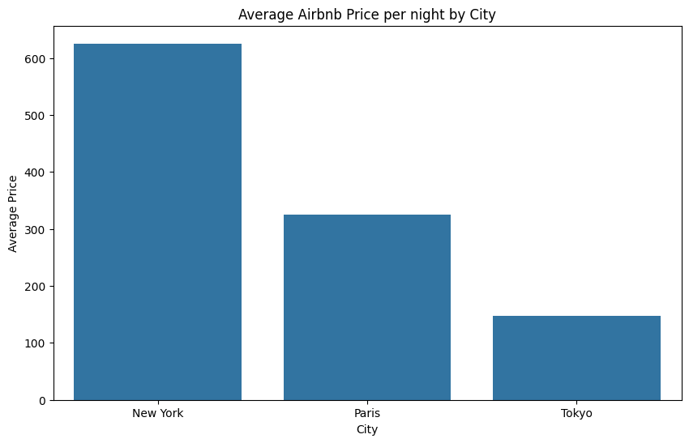

```python
# Average price per city
avg_price_city = airbnb_world.groupby('city')['price'].mean()

# Plot
plt.figure(figsize=(10, 6))
sns.barplot(x=avg_price_city.index, y=avg_price_city.values)
plt.xlabel('City')
plt.ylabel('Average Price')
plt.title('Average Airbnb Price per night by City')
plt.show()
```

New York is clearly the most expensive city on average, doubling Paris and more than tripling Tokyo. New York's Airbnb rentals tend to be more expensive on average compared to those in Tokyo and Paris due to several factors. Firstly, New York City's real estate market is notoriously pricey, driving up the cost of both long-term and short-term rentals. Additionally, the high demand for short-term accommodations in such a bustling, tourist-heavy city further inflates prices. In contrast, Tokyo and Paris, while also popular destinations, benefit from different economic conditions, regulatory environments, and housing markets that can offer relatively more affordable rental options.

**Compared Price Analysis**

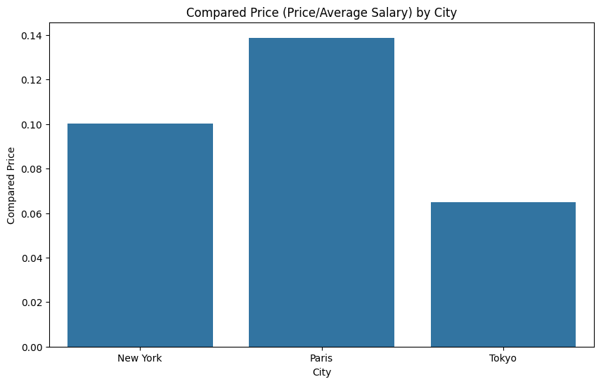

```python
# Average compared price per city
avg_compared_price_city = airbnb_world.groupby('city')['compared_price'].mean()

# Plot
plt.figure(figsize=(10, 6))
sns.barplot(x=avg_compared_price_city.index, y=avg_compared_price_city.values)
plt.xlabel('City')
plt.ylabel('Compared Price')
plt.title('Compared Price (Price/Average Salary) by City')
plt.show()
```

Despite New York's Airbnb rentals being more expensive in absolute terms, when comparing prices relative to the average national monthly salary, Paris stands out as having a higher ratio. This discrepancy arises because the cost of living in Paris, including housing costs, is relatively high compared to the average wages in France. Parisian salaries often do not keep pace with the cost of living, leading to a greater percentage of income being spent on accommodation. Conversely, New York's higher absolute rental prices are somewhat mitigated by generally higher salaries, which balance out the percentage of income spent on housing. Tokyo also benefits from a relatively balanced ratio between rental prices and average incomes, making its Airbnb costs more manageable in comparison to Paris.

**Room Type Distribution**

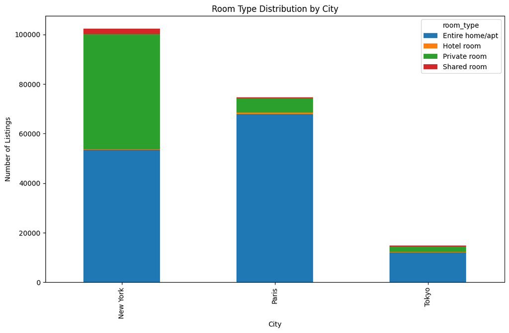

```python
# Room type distribution by city
room_type_city = airbnb_world.groupby(['city', 'room_type']).size().unstack().fillna(0)

# Plot
room_type_city.plot(kind='bar', stacked=True, figsize=(12, 7))
plt.xlabel('City')
plt.ylabel('Number of Listings')
plt.title('Room Type Distribution by City')
plt.show()
```

There is also a significant difference between the number of accommodations listed on the platform: New York has almost the same number of Paris and Tokyo combined. The diffusion of Airbnb in Japan is probably not as high as in Paris or New York

**Reviews Analysis**

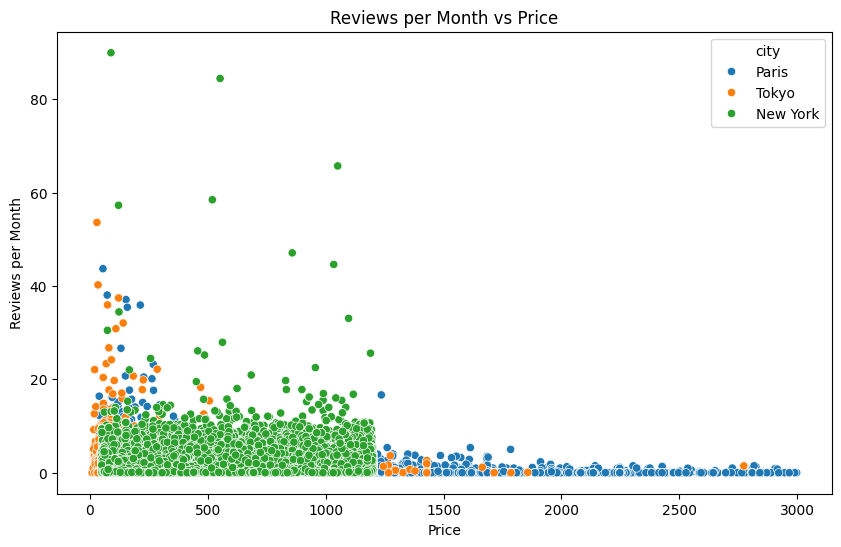

```python
# Excluding outliers
filtered_data = airbnb_world[airbnb_world['price'] <= 3000]

# Scatter plot for reviews per month vs price
plt.figure(figsize=(10, 6))
sns.scatterplot(x='price', y='reviews_per_month', hue='city', data=filtered_data)
plt.xlabel('Price')
plt.ylabel('Reviews per Month')
plt.title('Reviews per Month vs Price')
plt.show()
```

Overall, it appears that listings in New York tend to have a higher number of reviews compared to listings in Tokyo and New York, especially at lower price points. This could suggest that New York listings are generally more popular; this may be due to the fact that the city has more visitors, or that visitors use more Airbnbs than the other cities. However, as the price increases, the number of reviews for all three cities seems to decrease, indicating that more expensive listings might receive fewer reviews. This could be due to a variety of factors, such as higher prices deterring potential guests or fewer people staying in more expensive accommodations.

**Availability and Popularity Analysis**

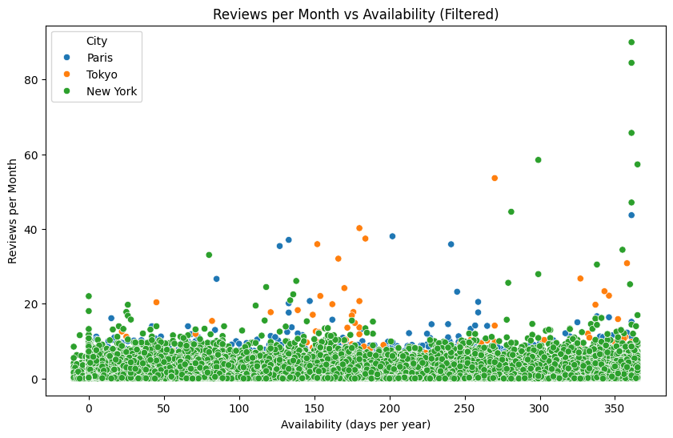

```
                   availability_365  reviews_per_month
availability_365           1.000000           0.058534
reviews_per_month          0.058534           1.000000
```

```python
# Filter out rows where 'availability_365' is greater than 365
filtered_data = airbnb_world[airbnb_world['availability_365'] <= 365]

# Scatter plot to show relationship between availability and reviews per month
plt.figure(figsize=(10, 6))
sns.scatterplot(x='availability_365', y='reviews_per_month', hue='city', data=filtered_data)
plt.xlabel('Availability (days per year)')
plt.ylabel('Reviews per Month')
plt.title('Reviews per Month vs Availability (Filtered)')
plt.legend(title='City')
plt.show()

# Analyzing correlation for filtered data
correlation = filtered_data[['availability_365', 'reviews_per_month']].corr()
print(correlation)
```

The low correlation is confirmed by the correlation value (0.06), which indicates a weak relationship.

**Neighborhood Analysis**

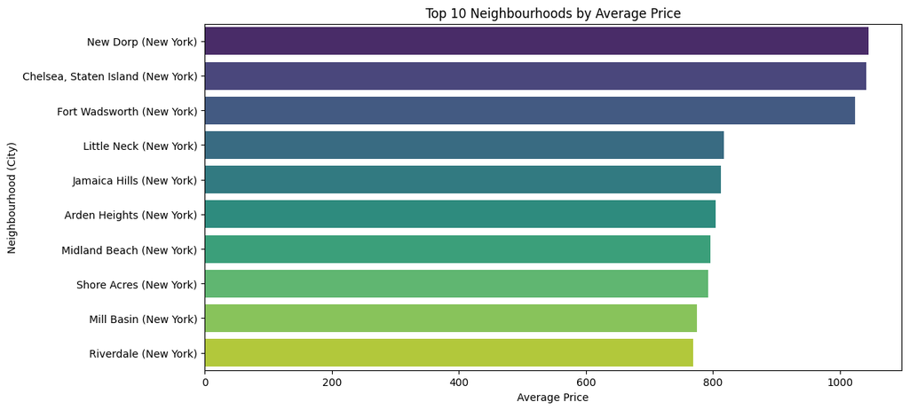

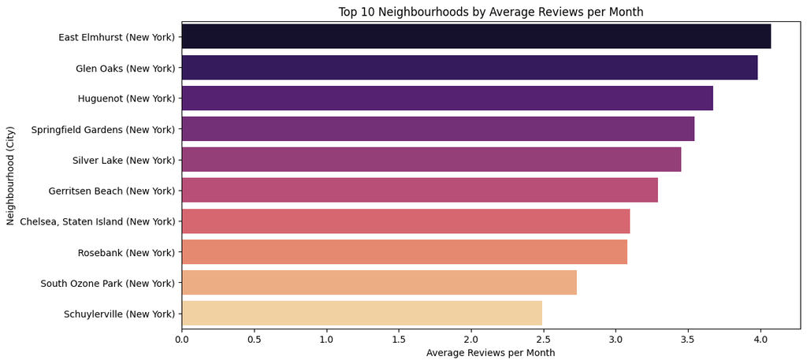

```python
# Convert 'neighbourhood' and 'city' columns to strings before concatenating
airbnb_world['neighbourhood'] = airbnb_world['neighbourhood'].astype(str)
airbnb_world['city'] = airbnb_world['city'].astype(str)

# Create a new column that combines neighborhood and city
airbnb_world['neighbourhood_city'] = airbnb_world['neighbourhood'] + ' (' + airbnb_world['city'] + ')'

# Calculate average price and average reviews per month by neighborhood and city
neighbourhood_stats = airbnb_world.groupby('neighbourhood_city').agg(
    avg_price=('price', 'mean'),
    avg_reviews=('reviews_per_month', 'mean')
).reset_index()

# Sort by average price to find top neighborhoods by price
top_neighbourhoods_by_price = neighbourhood_stats.sort_values(by='avg_price', ascending=False).head(10)

# Sort by average reviews to find top neighborhoods by reviews
top_neighbourhoods_by_reviews = neighbourhood_stats.sort_values(by='avg_reviews', ascending=False).head(10)

# Plotting top neighborhoods by average price
plt.figure(figsize=(12, 6))
sns.barplot(x='avg_price', y='neighbourhood_city', data=top_neighbourhoods_by_price, palette='viridis')
plt.xlabel('Average Price')
plt.ylabel('Neighbourhood (City)')
plt.title('Top 10 Neighbourhoods by Average Price')
plt.show()

# Plotting top neighborhoods by average reviews
plt.figure(figsize=(12, 6))
sns.barplot(x='avg_reviews', y='neighbourhood_city', data=top_neighbourhoods_by_reviews, palette='magma')
plt.xlabel('Average Reviews per Month')
plt.ylabel('Neighbourhood (City)')
plt.title('Top 10 Neighbourhoods by Average Reviews per Month')
plt.show()
```

The dominance of New York City in both the top 10 most expensive and top 10 most reviewed neighborhoods on Airbnb can be attributed to its unique combination of high demand, global appeal, and a diverse range of luxury and popular districts. New York's status as a major international hub for business, tourism, and culture drives up rental prices and generates significant review volume. The city's iconic neighborhoods attract both affluent visitors willing to pay premium rates and a high volume of reviews from tourists eager to experience its vibrant attractions. This concentration of high-priced, high-reviewed areas reflects New York's unparalleled global influence and the intense competition for prime real estate in its most sought-after locations.

**Time Trend Analysis**

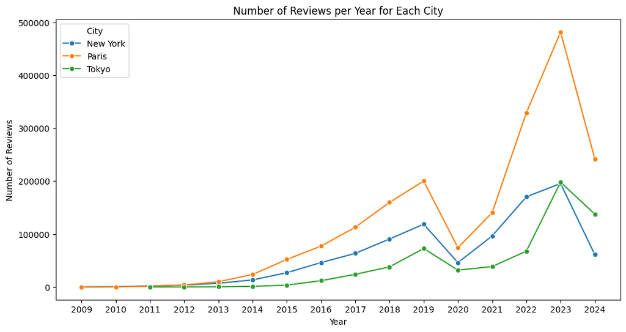

```python
# Ensure 'date' column is in datetime format
reviews_combined['date'] = pd.to_datetime(reviews_combined['date'])

# Extract year from the date and create a new 'year' column
reviews_combined['year'] = reviews_combined['date'].dt.year

# Group by city and year, then count the number of reviews for each group
reviews_per_year = reviews_combined.groupby(['city', 'year']).size().reset_index(name='review_count')

# Set the figure size for the plot
plt.figure(figsize=(12, 6))

# Plotting the trendline using seaborn
sns.lineplot(x='year', y='review_count', hue='city', data=reviews_per_year, marker='o')

# Adding titles and labels
plt.title('Number of Reviews per Year for Each City')
plt.xlabel('Year')
plt.ylabel('Number of Reviews')
plt.legend(title='City')
plt.xticks(reviews_per_year['year'].unique())  # Ensures all years are shown on x-axis

# Display the plot
plt.show()
```

**Minimum Stay Requirements**

```
Average Minimum Nights for Each Room Type and City:
          room_type      city  minimum_nights
0   Entire home/apt  New York        9.762843
1   Entire home/apt     Paris       10.517542
2   Entire home/apt     Tokyo        3.900306
3        Hotel room  New York        4.060345
4        Hotel room     Paris        3.028829
5        Hotel room     Tokyo        1.193182
6      Private room  New York        6.248741
7      Private room     Paris        4.686023
8      Private room     Tokyo        2.230667
9       Shared room  New York        6.604599
10      Shared room     Paris        2.275472
11      Shared room     Tokyo        2.394444
```

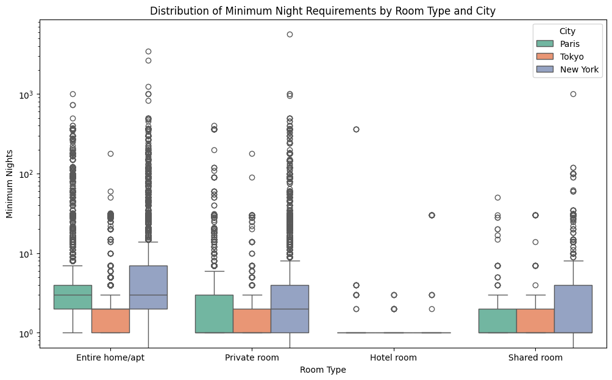

```python
# 1. Non-Visual: Calculate the average minimum nights for each room type and city
average_minimum_nights = airbnb_world.groupby(['room_type', 'city'])['minimum_nights'].mean().reset_index()

print("Average Minimum Nights for Each Room Type and City:")
print(average_minimum_nights)

# 2. Visual: Boxplot to compare the distribution of minimum nights required across room types and cities
plt.figure(figsize=(12, 7))

# Creating a boxplot
sns.boxplot(
    data=airbnb_world,
    x='room_type',
    y='minimum_nights',
    hue='city',
    palette='Set2'
)

# Adding labels and title
plt.xlabel('Room Type')
plt.ylabel('Minimum Nights')
plt.title('Distribution of Minimum Night Requirements by Room Type and City')
plt.legend(title='City')
plt.yscale('log')  # Use a logarithmic scale for better visualization if minimum nights vary widely
plt.show()
```

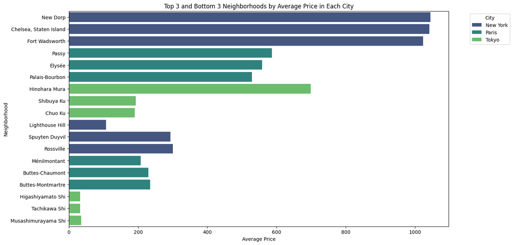

```python
# 1. Calculate the average price by neighborhood and city
avg_price_neighborhood = airbnb_world.groupby(['city', 'neighbourhood'])['price'].mean().reset_index()

# 2. Find the top 3 and bottom 3 neighborhoods by average price for each city
top_bottom_neighborhoods = pd.concat([
    avg_price_neighborhood.groupby('city').apply(lambda x: x.nlargest(3, 'price')),
    avg_price_neighborhood.groupby('city').apply(lambda x: x.nsmallest(3, 'price'))
]).reset_index(drop=True)

# 3. Visualize the data
plt.figure(figsize=(14, 8))

# Plotting
sns.barplot(
    data=top_bottom_neighborhoods,
    x='price',
    y='neighbourhood',
    hue='city',
    dodge=False,
    palette='viridis'
)

# Adding labels and title
plt.xlabel('Average Price')
plt.ylabel('Neighborhood')
plt.title('Top 3 and Bottom 3 Neighborhoods by Average Price in Each City')
plt.legend(title='City', bbox_to_anchor=(1.05, 1), loc='upper left')
plt.show()
```

These findings suggest that there is a significant disparity in housing costs among neighborhoods within each city, and that New York is generally more expensive than Paris and Tokyo, as previously discovered.

We can move on to exploring the trends within single cities. Let's start with Paris.

### Paris

**Trend of Average Price Over Time**

```python
# Convert 'date' to datetime format
merged_paris['date'] = pd.to_datetime(merged_paris['date'])

# Extract month and year
merged_paris['month_year'] = merged_paris['date'].dt.to_period('M')

# Calculate average price by month/year
average_price_trend = merged_paris.groupby('month_year')['price'].mean().reset_index()

# Convert month_year to string for better plotting
average_price_trend['month_year'] = average_price_trend['month_year'].astype(str)

# Create the Plotly line plot
fig = px.line(
    average_price_trend,
    x='month_year',
    y='price',
    title='Trend of Average Price Over Time',
    labels={'month_year': 'Month-Year', 'price': 'Average Price'},
    markers=True
)

# Customize the layout to improve the legend readability
fig.update_layout(
    xaxis_title='Month-Year',
    yaxis_title='Average Price',
    legend_title='Legend',
    legend=dict(
        x=1, # Position the legend outside the plot to the right
        y=1,
        traceorder='normal',
        orientation='v'
    ),
    xaxis=dict(
        tickangle=-45 # Rotate x-axis labels for better readability
    )
)

# Show the plot
fig.show()
```

The line chart illustrates the trend of average prices over time. The data spans from 2012 to 2024, showing a fluctuating pattern with a general upward trend. Prices reached a peak in 2015, followed by a period of decline until 2019. From 2019 onwards, prices have exhibited a relatively stable pattern, with some minor fluctuations. This suggests that while there have been periods of price increases and decreases, the overall trend has been upward over the past decade.

**Seasonal variation**

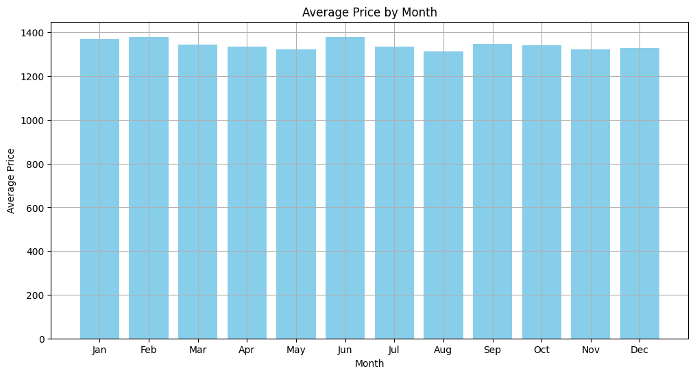

```python
# Calculate average price by month
monthly_avg_price = merged_paris.groupby(merged_paris['date'].dt.month)['price'].mean().reset_index()
monthly_avg_price.columns = ['Month', 'Average Price']

# Plotting
plt.figure(figsize=(12, 6))
plt.bar(monthly_avg_price['Month'], monthly_avg_price['Average Price'], color='skyblue')
plt.xlabel('Month')
plt.ylabel('Average Price')
plt.title('Average Price by Month')
plt.xticks(monthly_avg_price['Month'], ['Jan', 'Feb', 'Mar', 'Apr', 'May', 'Jun', 'Jul', 'Aug', 'Sep', 'Oct', 'Nov', 'Dec'])
plt.grid(True)
plt.show()
```

**Distribution of prices by roomtype**

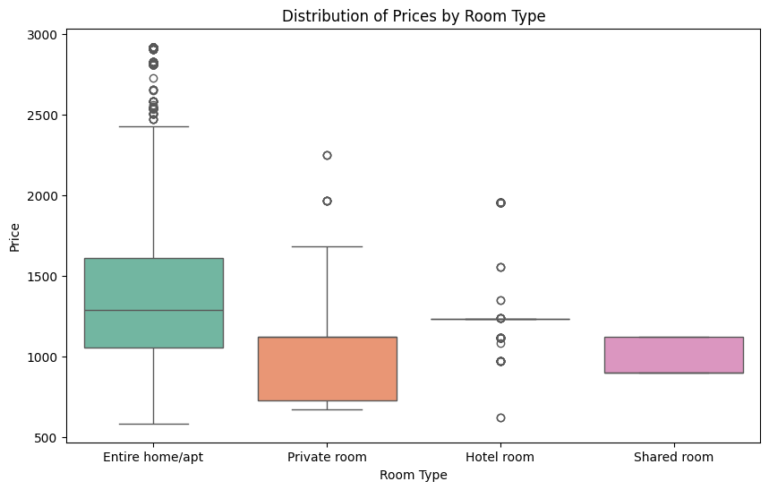

```python
# Create a box plot using seaborn
plt.figure(figsize=(10, 6))  # Set the figure size
sns.boxplot(
    x='room_type',
    y='price',
    data=merged_paris,
    palette='Set2'  # Different colors for each room type
)

# Set the title and labels
plt.title('Distribution of Prices by Room Type')
plt.xlabel('Room Type')
plt.ylabel('Price')

# Show the plot
plt.show()
```

**Neighborhood Pricing Insights**

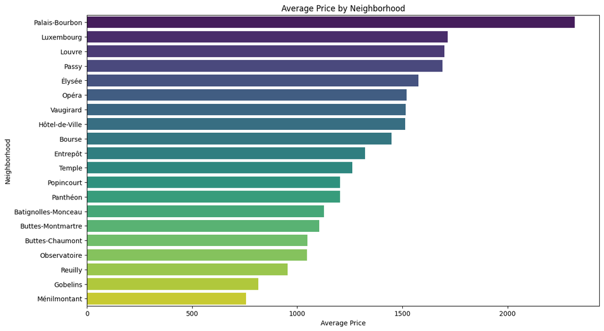

```python
# Calculate average price by neighborhood
avg_price_neighborhood = merged_paris.groupby('neighbourhood')['price'].mean().reset_index()

# Sort by average price in descending order
avg_price_neighborhood = avg_price_neighborhood.sort_values(by='price', ascending=False)

# Plotting
plt.figure(figsize=(14, 8))
sns.barplot(data=avg_price_neighborhood, x='price', y='neighbourhood', palette='viridis')
plt.xlabel('Average Price')
plt.ylabel('Neighborhood')
plt.title('Average Price by Neighborhood')
plt.show()
```

Palais-Bourbon and Luxembourg emerge as the most expensive neighborhoods, likely due to their prime locations near government buildings and historical landmarks. These areas are highly sought after, driving up property prices. Louvre and Passy also command high prices, owing to their proximity to renowned cultural attractions and upscale shopping districts. The reputation and desirability of these neighborhoods contribute to their premium pricing.

Other neighborhoods are more suited for families and are more far away from the city center. In general the average price of neighborhoods in Paris varies significantly. Central neighborhoods near government buildings, historical landmarks, and cultural attractions are typically more expensive. Areas with residential character and green spaces tend to be more affordable. Paris offers a wide range of housing options to suit different budgets and preferences.

**Correlation between distance from city center and price**

```
Correlation between price and distance from city center:
                         price  distance_from_center
price                 1.000000             -0.017459
distance_from_center -0.017459              1.000000
```

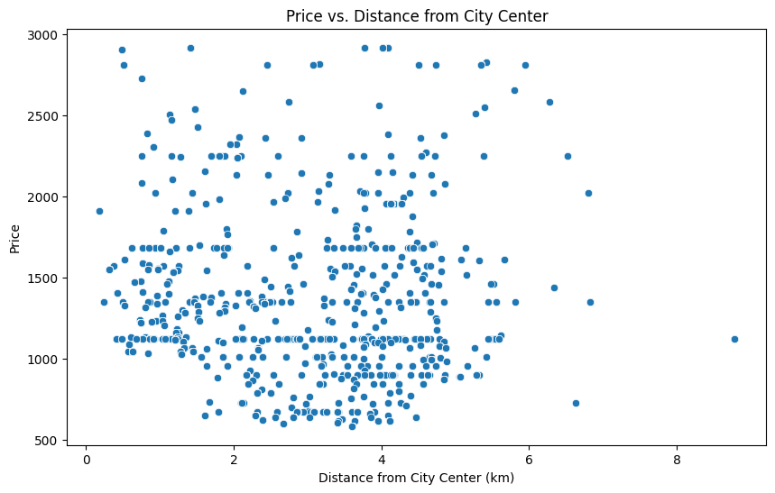

```python
# Define the city center coordinates (Notre-Dame Cathedral)
city_center_lat = 48.8566
city_center_lon = 2.3522

# Function to calculate distance using Haversine formula
def haversine_distance(lat1, lon1, lat2, lon2):
    R = 6371  # Earth radius in kilometers
    lat1, lon1, lat2, lon2 = map(np.radians, [lat1, lon1, lat2, lon2])
    dlat = lat2 - lat1
    dlon = lon2 - lon1
    a = np.sin(dlat/2)**2 + np.cos(lat1) * np.cos(lat2) * np.sin(dlon/2)**2
    c = 2 * np.arcsin(np.sqrt(a))
    return R * c

# Calculate distance from city center for each listing
merged_paris['distance_from_center'] = merged_paris.apply(
    lambda row: haversine_distance(city_center_lat, city_center_lon, row['latitude'], row['longitude']), axis=1
)

# Calculate correlation between price and distance
correlation = merged_paris[['price', 'distance_from_center']].corr()
print("Correlation between price and distance from city center:")
print(correlation)

# Plot the relationship between price and distance
plt.figure(figsize=(10, 6))
sns.scatterplot(data=merged_paris, x='distance_from_center', y='price')
plt.xlabel('Distance from City Center (km)')
plt.ylabel('Price')
plt.title('Price vs. Distance from City Center')
plt.show()
```

As the correlation value suggests, there seems not to be a correlation between these two parameters. This is probably because each neighborhood has some expensive stays, maybe because of the amenities, maybe because of different benefits, such as being close to the subway, which in Paris is a good and cheap way to move around the city.

### Tokyo

The analysis for Tokyo will follow the exact same steps as the one for Paris.

**Trend of Average Price Over Time**

```python
# Convert 'date' to datetime format
merged_tokyo['date'] = pd.to_datetime(merged_tokyo['date'])

# Extract month and year
merged_tokyo['month_year'] = merged_tokyo['date'].dt.to_period('M')

# Calculate average price by month/year
average_price_trend_tokyo = merged_tokyo.groupby('month_year')['price'].mean().reset_index()

# Convert month_year to string for better plotting
average_price_trend_tokyo['month_year'] = average_price_trend_tokyo['month_year'].astype(str)

# Create the Plotly line plot
fig = px.line(
    average_price_trend_tokyo,
    x='month_year',
    y='price',
    title='Trend of Average Price Over Time in Tokyo',
    labels={'month_year': 'Month-Year', 'price': 'Average Price'},
    markers=True
)

# Customize the layout to improve the legend readability
fig.update_layout(
    xaxis_title='Month-Year',
    yaxis_title='Average Price',
    legend_title='Legend',
    legend=dict(
        x=1, # Position the legend outside the plot to the right
        y=1,
        traceorder='normal',
        orientation='v'
    ),
    xaxis=dict(
        tickangle=-45 # Rotate x-axis labels for better readability
    )
)

# Show the plot
fig.show()
```

Tokyo's data spans from 2014 to 2024, showing a fluctuating pattern with a general upward trend. Prices reached a peak in 2020, followed by a period of decline until 2022 probably due to the pandemic. From 2022 onwards, prices have exhibited a relatively stable pattern, with some minor fluctuations. This suggests that while there have been periods of price increases and decreases, the overall trend has been upward over the past decade.

**Seasonal variation**

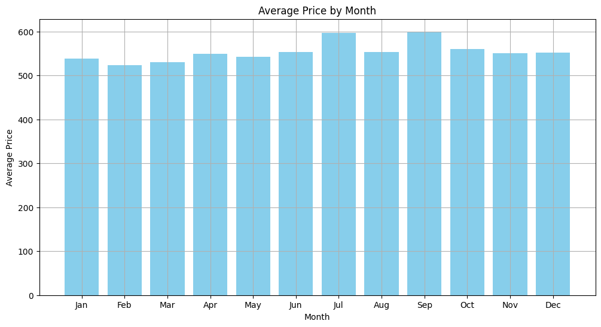

```python
# Calculate average price by month
monthly_avg_price = merged_tokyo.groupby(merged_tokyo['date'].dt.month)['price'].mean().reset_index()
monthly_avg_price.columns = ['Month', 'Average Price']

# Plotting
plt.figure(figsize=(12, 6))
plt.bar(monthly_avg_price['Month'], monthly_avg_price['Average Price'], color='skyblue')
plt.xlabel('Month')
plt.ylabel('Average Price')
plt.title('Average Price by Month')
plt.xticks(monthly_avg_price['Month'], ['Jan', 'Feb', 'Mar', 'Apr', 'May', 'Jun', 'Jul', 'Aug', 'Sep', 'Oct', 'Nov', 'Dec'])
plt.grid(True)
plt.show()
```

**Distribution of prices by roomtype**

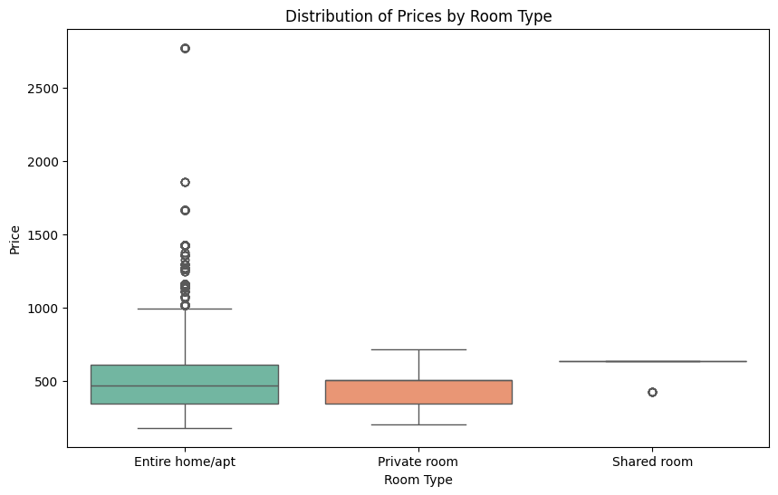

```python
# Create a box plot using seaborn
plt.figure(figsize=(10, 6))  # Set the figure size
sns.boxplot(
    x='room_type',
    y='price',
    data=merged_tokyo,
    palette='Set2'  # Different colors for each room type
)

# Set the title and labels
plt.title('Distribution of Prices by Room Type')
plt.xlabel('Room Type')
plt.ylabel('Price')

# Show the plot
plt.show()
```

**Neighborhood Pricing Insights**

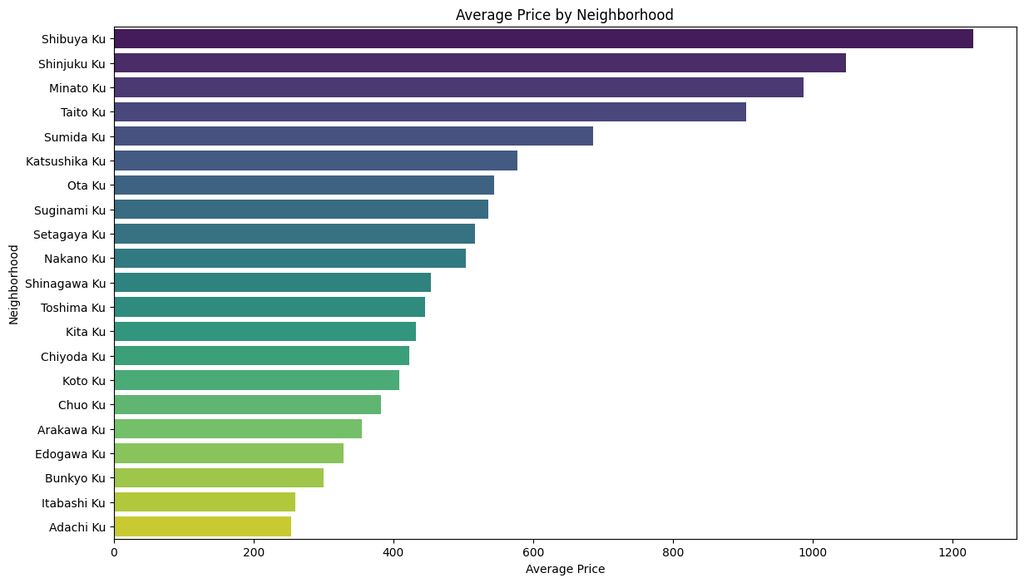

```python
# Calculate average price by neighborhood
avg_price_neighborhood = merged_tokyo.groupby('neighbourhood')['price'].mean().reset_index()

# Sort by average price in descending order
avg_price_neighborhood = avg_price_neighborhood.sort_values(by='price', ascending=False)

# Plotting
plt.figure(figsize=(14, 8))
sns.barplot(data=avg_price_neighborhood, x='price', y='neighbourhood', palette='viridis')
plt.xlabel('Average Price')
plt.ylabel('Neighborhood')
plt.title('Average Price by Neighborhood')
plt.show()
```

Shibuya Ku, Shinjuku Ku, and Minato Ku emerge as the most expensive neighborhoods, likely due to their prime locations, proximity to major transportation hubs, and concentration of commercial and entertainment districts. These areas are highly sought after, driving up property prices.

Neighborhoods like Nakano Ku, Shinagawa Ku, and Toshima Ku are known for their residential character and green spaces, making them more desirable for families and those seeking a quieter environment. Their average prices are generally lower than the central neighborhoods.

As for Paris, the range is wide and there are neighborhoods to suit different budgets and preferences.

**Correlation between distance from city center and price**

```
Correlation between price and distance from city center in Tokyo (using Chiyoda as center):
                         price  distance_from_center
price                 1.000000             -0.169534
distance_from_center -0.169534              1.000000
```

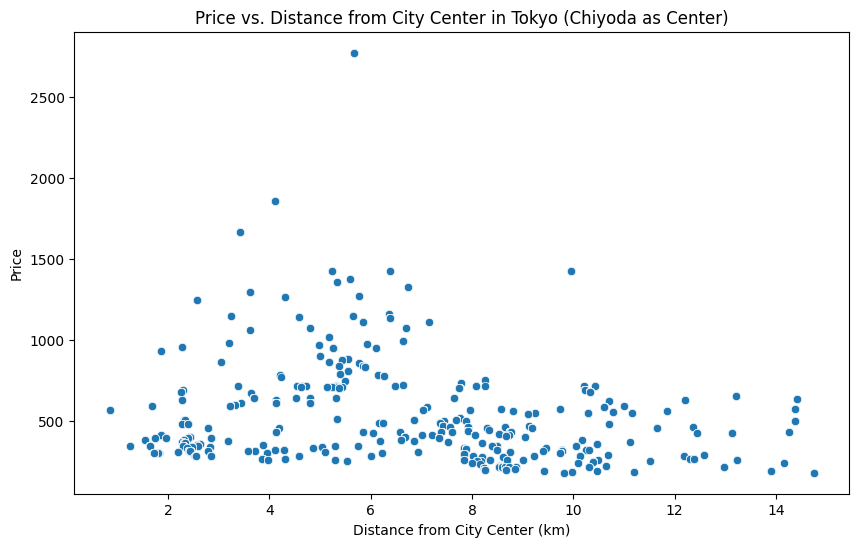

```python
# Define the city center coordinates (Chiyoda City, near Imperial Palace)
city_center_lat_tokyo = 35.682839
city_center_lon_tokyo = 139.759455

# Function to calculate distance using Haversine formula (reuse from previous example)
def haversine_distance(lat1, lon1, lat2, lon2):
    R = 6371  # Earth radius in kilometers
    lat1, lon1, lat2, lon2 = map(np.radians, [lat1, lon1, lat2, lon2])
    dlat = lat2 - lat1
    dlon = lon2 - lon1
    a = np.sin(dlat/2)**2 + np.cos(lat1) * np.cos(lat2) * np.sin(dlon/2)**2
    c = 2 * np.arcsin(np.sqrt(a))
    return R * c

# Calculate distance from city center for each listing in Tokyo
merged_tokyo['distance_from_center'] = merged_tokyo.apply(
    lambda row: haversine_distance(city_center_lat_tokyo, city_center_lon_tokyo, row['latitude'], row['longitude']), axis=1
)

# Calculate correlation between price and distance
correlation_tokyo = merged_tokyo[['price', 'distance_from_center']].corr()
print("Correlation between price and distance from city center in Tokyo (using Chiyoda as center):")
print(correlation_tokyo)

# Plot the relationship between price and distance
plt.figure(figsize=(10, 6))
sns.scatterplot(data=merged_tokyo, x='distance_from_center', y='price')
plt.xlabel('Distance from City Center (km)')
plt.ylabel('Price')
plt.title('Price vs. Distance from City Center in Tokyo (Chiyoda as Center)')
plt.show()
```

In Tokyo's case the correlation is slightly stronger, but still pretty weak. Several outliers can be observed, such as the high-priced property around 4 kilometers from the city center. These outliers might be due to factors like unique property characteristics, historical significance, or exceptional amenities. The data points tend to cluster in certain areas, particularly between 5 and 10 kilometers from the city center. This might indicate a higher concentration of properties within these distance ranges.

These factors could explain why the relationship is not so strong.

## New York

Since the merged_ny dataset is limited, I will use that for time based statistics, while I'll use airbnb_newyork for other types of graphs and observations.

```python
# Group by 'neighbourhood group' and count the number of unique listings based on 'id'
unique_listings_count_by_ng = merged_ny.groupby('neighbourhood group')['id'].nunique().reset_index(name='unique_listings_count')

# Sort the results by count in descending order (optional)
unique_listings_count_by_ng = unique_listings_count_by_ng.sort_values(by='unique_listings_count', ascending=False)

# Display the result
print(unique_listings_count_by_ng)
```

```
  neighbourhood group  unique_listings_count
1            Brooklyn                     13
2           Manhattan                     13
3              Queens                      4
0               Bronx                      1
```

```python
# Group by 'neighbourhood group' and count the number of unique listings based on 'id'
unique_listings_count_by_ng = airbnb_newyork.groupby('neighbourhood group')['id'].nunique().reset_index(name='unique_listings_count')

# Sort the results by count in descending order (optional)
unique_listings_count_by_ng = unique_listings_count_by_ng.sort_values(by='unique_listings_count', ascending=False)

# Display the result
print(unique_listings_count_by_ng)
```

```
  neighbourhood group  unique_listings_count
3           Manhattan                  43448
2            Brooklyn                  41538
4              Queens                  13164
1               Bronx                   2687
5       Staten Island                    946
0                   0                     28
```

As we can see, the difference in dimensions is significant.

Since it wasn't filtered before (because otherwise the merged one would have been even smaller), I'll do it now.

```python
# Sort in descending order, using the 'ascending' parameter
sorted_ny_desc = airbnb_newyork.sort_values(by='price', ascending=False)

# Group by 'neighbourhood' and take the first 500 IDs for each group
airbnb_newyork = sorted_ny_desc.groupby('neighbourhood').head(500)

airbnb_newyork.head()
```

|  | id | neighbourhood group | neighbourhood | lat | long | room_type | Construction year | price | service fee | minimum_nights | last_review | reviews_per_month | availability_365 | city |
| --- | --- | --- | --- | --- | --- | --- | --- | --- | --- | --- | --- | --- | --- | --- |
| 64304 | 36516435 | Bronx | City Island | 40.85343 | -73.78811 | Entire home/apt | 2019.0 | 1200.0 | 240.0 | 30.0 | 2021-08-25 | 1.09 | 31.0 | New York |
| 70765 | 40084846 | Manhattan | Harlem | 40.80861 | -73.94574 | Entire home/apt | 2014.0 | 1200.0 | 240.0 | 3.0 | 2019-07-02 | 1.73 | 248.0 | New York |
| 23345 | 13894780 | Queens | Flushing | 40.75575 | -73.83261 | Private room | 2017.0 | 1200.0 | 240.0 | 2.0 | 2019-05-06 | 1.77 | 45.0 | New York |
| 38851 | 22458743 | Brooklyn | Bushwick | 40.68583 | -73.90985 | Private room | 2015.0 | 1200.0 | 240.0 | 1.0 | 2019-05-06 | 1.36 | 365.0 | New York |
| 102191 | 35580287 | Staten Island | Shore Acres | 40.61126 | -74.06789 | Private room | 2019.0 | 1200.0 | 240.0 | 1.0 | 2021-11-07 | 0.59 | 0.0 | New York |

**Trend of Average Price Over Time**

```python
# Convert 'date' to datetime format
merged_ny['date'] = pd.to_datetime(merged_ny['date'])

# Extract month and year
merged_ny['month_year'] = merged_ny['date'].dt.to_period('M')

# Calculate average price by month/year
average_price_trend_ny = merged_ny.groupby('month_year')['price'].mean().reset_index()

# Convert month_year to string for better plotting
average_price_trend_ny['month_year'] = average_price_trend_ny['month_year'].astype(str)

# Create the Plotly line plot
fig = px.line(
    average_price_trend_ny,
    x='month_year',
    y='price',
    title='Trend of Average Price Over Time in New York',
    labels={'month_year': 'Month-Year', 'price': 'Average Price'},
    markers=True
)

# Customize the layout to improve the legend readability
fig.update_layout(
    xaxis_title='Month-Year',
    yaxis_title='Average Price',
    legend_title='Legend',
    legend=dict(
        x=1, # Position the legend outside the plot to the right
        y=1,
        traceorder='normal',
        orientation='v'
    ),
    xaxis=dict(
        tickangle=-45 # Rotate x-axis labels for better readability
    )
)

# Show the plot
fig.show()
```

The data spans from 2014 to 2024, showing a fluctuating pattern with a general upward trend. Prices reached a peak in 2016, followed by a period of decline until 2019. From 2019 onwards, prices have exhibited a relatively stable pattern, with some minor fluctuations. This suggests that while there have been periods of price increases and decreases, the overall trend has been upward over the past decade.

New York seems to have suffered less consequences than Tokyo and Paris from the pandemic. There is a downwards spike in 2021, but in the second part of 2021 prices seem to have stabilized once again, despite some fluctuations.

**Seasonal variation**

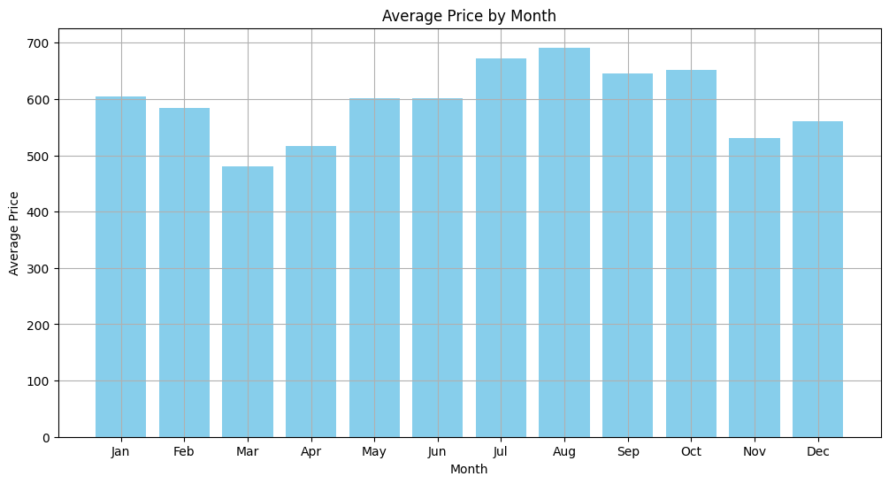

```python
# Calculate average price by month
monthly_avg_price = merged_ny.groupby(merged_ny['date'].dt.month)['price'].mean().reset_index()
monthly_avg_price.columns = ['Month', 'Average Price']

# Plotting
plt.figure(figsize=(12, 6))
plt.bar(monthly_avg_price['Month'], monthly_avg_price['Average Price'], color='skyblue')
plt.xlabel('Month')
plt.ylabel('Average Price')
plt.title('Average Price by Month')
plt.xticks(monthly_avg_price['Month'], ['Jan', 'Feb', 'Mar', 'Apr', 'May', 'Jun', 'Jul', 'Aug', 'Sep', 'Oct', 'Nov', 'Dec'])
plt.grid(True)
plt.show()
```

**Distribution of prices by roomtype**

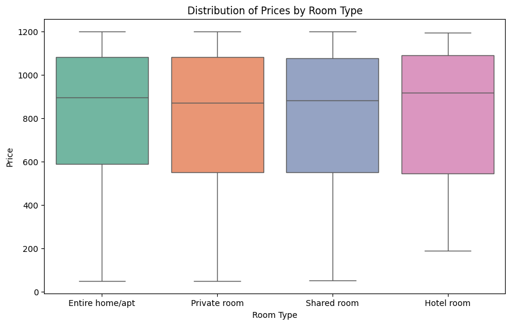

```python
# Create a box plot using seaborn
plt.figure(figsize=(10, 6))  # Set the figure size
sns.boxplot(
    x='room_type',
    y='price',
    data=airbnb_newyork,
    palette='Set2'  # Different colors for each room type
)

# Set the title and labels
plt.title('Distribution of Prices by Room Type')
plt.xlabel('Room Type')
plt.ylabel('Price')

# Show the plot
plt.show()
```

**Average price by neighborhood group**

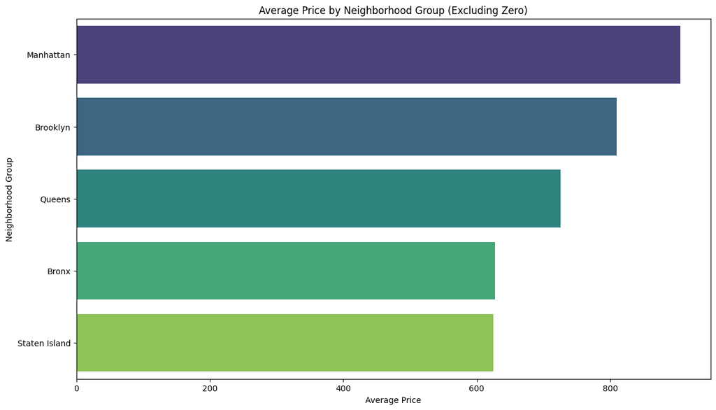

```python
# Filter out rows where 'neighbourhood group' is 0
filtered_airbnb_ny = airbnb_newyork[airbnb_newyork['neighbourhood group'] != 0]

# Calculate average price by neighborhood group
avg_price_neighborhood = filtered_airbnb_ny.groupby('neighbourhood group')['price'].mean().reset_index()

# Sort by average price in descending order
avg_price_neighborhood = avg_price_neighborhood.sort_values(by='price', ascending=False)

# Plotting
plt.figure(figsize=(14, 8))
sns.barplot(data=avg_price_neighborhood, x='price', y='neighbourhood group', palette='viridis')
plt.xlabel('Average Price')
plt.ylabel('Neighborhood Group')
plt.title('Average Price by Neighborhood Group (Excluding Zero)')
plt.show()
```

Manhattan stands out as the neighborhood group with the highest average price, significantly surpassing the other boroughs. This reflects the high demand and desirability of properties in Manhattan. Brooklyn comes in second with a notably lower average price compared to Manhattan, but still higher than Queens and the Bronx. Queens and the Bronx exhibit similar average prices, with the Bronx slightly lower. These boroughs offer a more affordable housing market compared to Manhattan and Brooklyn. Staten Island has the lowest average price among the five boroughs, indicating a more budget-friendly option for homebuyers.

Manhattan's prime location, central business districts, cultural attractions, and high accessibility contribute to its premium pricing. Brooklyn, while still desirable, is generally considered more affordable than Manhattan. Queens and the Bronx offer a mix of residential and commercial areas, with varying levels of affordability. Staten Island, being more suburban and less densely populated, tends to have lower housing prices.

**Price vs. Distance from City Center in New York City**

```
Correlation between price and distance from city center in New York City (using Midtown Manhattan as center) excluding distances >1000 km:
                         price  distance_from_center
price                 1.000000             -0.299835
distance_from_center -0.299835              1.000000
```

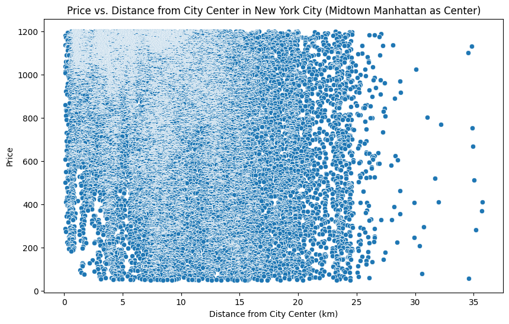

```python
# Define the city center coordinates (Midtown Manhattan)
city_center_lat_nyc = 40.754932
city_center_lon_nyc = -73.984016

# Function to calculate distance using Haversine formula
def haversine_distance(lat1, lon1, lat2, lon2):
    R = 6371  # Earth radius in kilometers
    lat1, lon1, lat2, lon2 = map(np.radians, [lat1, lon1, lat2, lon2])
    dlat = lat2 - lat1
    dlon = lon2 - lon1
    a = np.sin(dlat/2)**2 + np.cos(lat1) * np.cos(lat2) * np.sin(dlon/2)**2
    c = 2 * np.arcsin(np.sqrt(a))
    return R * c

# Calculate distance from city center for each listing in New York City
airbnb_newyork['distance_from_center'] = airbnb_newyork.apply(
    lambda row: haversine_distance(city_center_lat_nyc, city_center_lon_nyc, row['lat'], row['long']), axis=1
)

# Filter out rows with distance greater than 1000 km
filtered_nyc = airbnb_newyork[airbnb_newyork['distance_from_center'] <= 1000]

# Calculate correlation between price and distance
correlation_nyc = filtered_nyc[['price', 'distance_from_center']].corr()
print("Correlation between price and distance from city center in New York City (using Midtown Manhattan as center) excluding distances >1000 km:")
print(correlation_nyc)

# Plot the relationship between price and distance
plt.figure(figsize=(10, 6))
sns.scatterplot(data=filtered_nyc, x='distance_from_center', y='price')
plt.xlabel('Distance from City Center (km)')
plt.ylabel('Price')
plt.title('Price vs. Distance from City Center in New York City (Midtown Manhattan as Center)')
plt.show()
```

Although the correlation is stronger than Tokyo and Paris, the data seems to suggest that there are all sort of prices for all sort of positions in the city.

**Price vs. Construction Year**

```python
# Filter out rows where 'Construction year' is 0
filtered_data = airbnb_newyork[airbnb_newyork['Construction year'] != 0]

# Create a scatter plot using Plotly
fig = px.scatter(
    filtered_data,
    x='Construction year',
    y='price',
    title='Price vs. Construction Year',
    labels={'Construction year': 'Construction Year', 'price': 'Price'}
)

# Show the plot
fig.show()
```

This graph shows that for each construction year there is a large variety in prices. There doesn't seem to be any correlation between construction year and price. Many older properties in New York City have undergone renovations or modernizations to improve their appeal and functionality. These updates can make older properties comparable or even superior to newer ones, reducing the impact of construction year on pricing. The location and neighborhood of a property often play a more significant role in determining its price than its age. Properties in desirable neighborhoods with good access to transportation, amenities, and attractions may command higher prices regardless of their construction year. Properties with unique features or historical significance can also influence pricing. For example, a historic building or a property with a unique view might be priced higher, regardless of its age.

**New York room type distribution map**

```python
# Create a scatter map plot using Plotly
fig = px.scatter_mapbox(
    airbnb_newyork,
    lat='lat',
    lon='long',
    color='room_type',  # Column that represents different room types
    mapbox_style="carto-positron",  # Map style
    title='Geographical Distribution of Room Types in New York',
    hover_name='neighbourhood',  # Column that will appear when you hover over points
    hover_data=['price', 'minimum_nights', 'reviews_per_month'],  # Additional data on hover
    zoom=10  # Zoom level for the map
)

# Show the plot
fig.show()
```

**Entire Homes/Apartments Dominate**: In most areas of New York City, entire homes/apartments are the most common room type. This suggests that many travelers prefer having their own space, especially in a city like New York.

**Private Rooms in Central Manhattan**: Private rooms are particularly prevalent in central Manhattan, especially in areas like Midtown and the Upper East and West Sides. This may be due to the high cost of entire apartments in these areas, making private rooms a more affordable option for some travelers. Shared Rooms Less Common: Shared rooms are relatively less common in New York City compared to entire homes/apartments and private rooms. This might suggest that travelers generally prefer more privacy, especially in a major city like New York.

**Hotel Rooms in Outer Boroughs**: Hotel rooms are more common in the outer boroughs, such as Queens and Staten Island. This could be attributed to the presence of traditional hotels and motels in these areas, catering to a different market segment.

## Conclusions

This analysis reveals distinct differences in the Airbnb rental markets of New York, Paris, and Tokyo, driven by each city’s unique real estate landscape, economic conditions, and tourism demands. New York stands out as the most expensive city, with Airbnb prices that are significantly higher than those in Paris and Tokyo. This is due to the city’s costly real estate, high demand from international tourists, and preference for entire homes/apartments over other types of accommodations. Paris, while less expensive in absolute terms than New York, has a higher cost-to-income ratio due to the relatively high cost of living and moderate wages. In Paris, luxury hotel rooms are more prevalent, reflecting the city’s reputation for historic and high-end accommodations. Tokyo offers the most balanced market, with affordable rental prices relative to incomes, driven by a preference for hotels and a well-developed infrastructure catering to both local and international tourists.

Within each city, internal disparities are evident. In New York, Manhattan leads with the highest prices, followed by Brooklyn, while Queens, the Bronx, and Staten Island offer more budget-friendly options. Paris showcases a divide between expensive central areas like Palais-Bourbon and more affordable neighborhoods like Ménilmontant. In Tokyo, upscale areas such as Shibuya Ku command higher prices, whereas residential districts like Nakano Ku offer more affordable options.